# **Facial Emotion Detection**

## **Problem Definition**

**The context:** Why is this problem important to solve? The abbility to comminucate, has been the root of human society since ancient times. As social animals, this is vital, but before language existed, we were able to communicate emotions through our hairless faces, eyebrows, eyes, mouth and nouse. So many subtle details that we evolved to learn and reproduce. Long has been the time since the horizon of men, technology has advanced, adn we keep true to our emotions and expressions. As we created computers, the desire of improving communication with our creation has never stopped. We have evolved with them from 0s and 1s, to cryptic languiage, to fluent language and voice.

With the help of data science we can also peek into a more complete virtual communication.

**The objectives:** What is the intended goal? To build a model, capable of recognizing simple human expression. We will have 4 categories: happy, sad, neutral and suprised.

**The key questions:**

What are the key questions that need to be answered?

- Is the model capable of reading human emotions with confidence? Yes, most of the 4 classes are predicted correctly.
- On what confidence interval? Between 76% and 89% with 95% confidence.
- How well does mi model read human emotions? It is capable of reading most of the emotions well, with an accuracy of 0.8 in our 4 categories.

**What patterns has it detected?** By looking at the confusion matrix, the faces with the most recognizable patterns in their mouth and eyebrows had the best scores.

**How fast does the model work?** It has an average time per image of 2.35 ms

**Is this a practical application?** Yes, even though the data is small in resolution, it has a practical application with regular pictures. The model weights can be saved for practical applications, including healthcare, human-computer interaction, marketing, and security.

**The problem formulation: What are we trying to solve using data science?**

We are trying to detect the main features that define an emotion on the human face. With data science, we can find these patterns with CNNs, learn from the data, and accurately make predictions.

## **About the dataset**

The data set consists of 3 folders, i.e., 'test', 'train', and 'validation'. Each of these folders has four subfolders:

**‘happy’**: Images of people who have happy facial expressions.  
**‘sad’**: Images of people with sad or upset facial expressions.  
**‘surprise’**: Images of people who have shocked or surprised facial expressions.  
**‘neutral’**: Images of people showing no prominent emotion in their facial expression at all.

## **Mounting the Drive**

**NOTE:** Please use Google Colab from your browser for this notebook. **Google.colab is NOT a library that can be downloaded locally on your device.**

```python
# Import and mount google Drive

from google.colab import drive
drive.mount('/content/drive')
```

## **Importing the Libraries**

```python
# Install tensorflow as it is not pre-installed

!pip install tensorflow
```

```python
# Essentials
import pandas as pd
import numpy as np
import os

# File format
import zipfile

# Plotting
import matplotlib.pyplot as plt
import seaborn as sns

# Models
import tensorflow as tf
from tensorflow.keras.models import Sequential, Model
from tensorflow.keras.applications.vgg16 import VGG16
import tensorflow.keras.applications as ap

# Layers and optimizers
from tensorflow.keras.layers import Flatten, Dense, Activation, LeakyReLU, Dropout, Conv2D, MaxPooling2D, BatchNormalization, GlobalAveragePooling2D
from tensorflow.keras.optimizers import Adam

# Callbacks
from keras.callbacks import ModelCheckpoint, EarlyStopping, ReduceLROnPlateau

# Metrics
from sklearn.metrics import classification_report, confusion_matrix

# Image
from tensorflow.keras.preprocessing.image import load_img, img_to_array
from tensorflow.keras.preprocessing.image import ImageDataGenerator
from tensorflow.keras.utils import image_dataset_from_directory
from tensorflow.keras.layers import RandomRotation
from tensorflow.keras.applications.vgg16 import preprocess_input

# Clear
import gc

# Warnings
import warnings
warnings.filterwarnings('ignore')
```

```python
# Check version
print(tf.__version__)
```

```
2.18.0
```

### **Let us load and unzip the data**

**Note:**

- You must download the dataset from the link provided on Olympus and upload the same on your Google drive before executing the code in the next cell.
- In case of any error, please make sure that the path of the file is correct as the path may be different for you.

```python
# Path
path = '/content/Facial_emotion_images.zip'
```

```python
# Extracrt file
with zipfile.ZipFile(path, 'r') as zip_ref:
    zip_ref.extractall('/content/')
```

```python
picture_size = 48
folder_path = '/content/Facial_emotion_images/'
```

## **Visualizing our Classes**

Let's look at our classes.

**Write down your observation for each class. What do you think can be a unique feature of each emotion, that separates it from the remaining classes?**

### **Happy**

```python
# Create a function to avoid repetitive code
def print_expression(expression):
  plt.figure(figsize= (8,8))
  for i in range(1, 10, 1):
    plt.subplot(3, 3, i)
    img = load_img(folder_path + "train/" + expression + "/" +
                  os.listdir(folder_path + "train/" + expression)[i], target_size = (picture_size, picture_size))
    plt.imshow(img)
  plt.show()
```

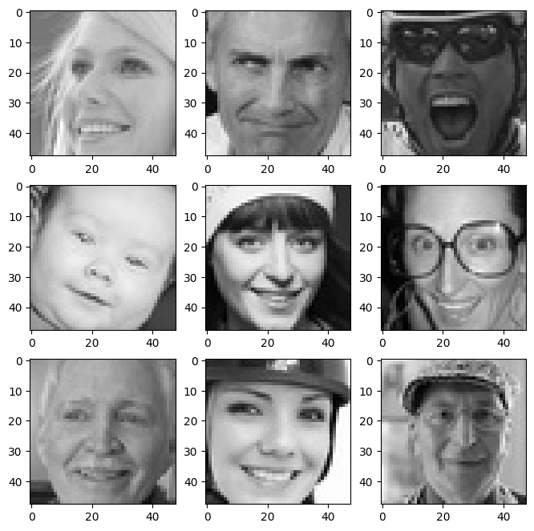

```python
print_expression('happy')
```

**Observations and Insights**: "The data includes faces from different ethnicities and ages. The shape of the lips would be the primary indicator of this emotion, along with most of them showing their teeth. We can also see the curve of the eyebrows in an open position. The lines of expression around the mouth also indicate happiness."

### **Sad**

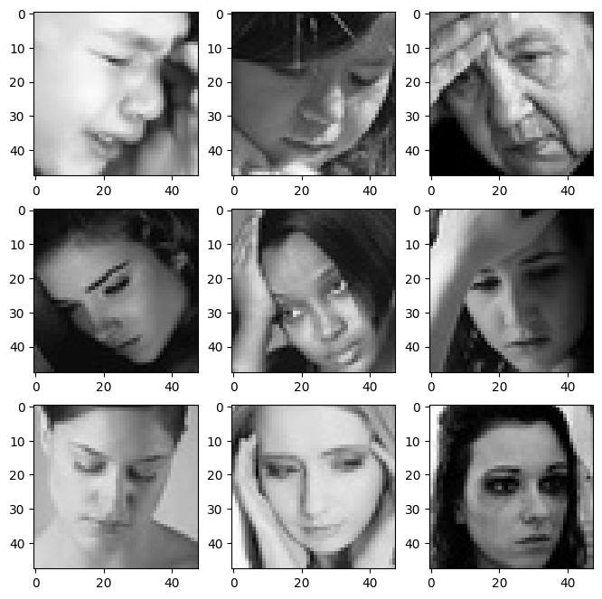

```python
print_expression('sad')
```

**Observations and Insights:** Again, the data is varied. Most sad expressions can be determined by the closed curve of the eyebrows. Also, the mouth has a closed curve tilting downward. Between the eyebrows, we can see lines of expression on the forehead. The eyes are semi-closed.

### **Neutral**

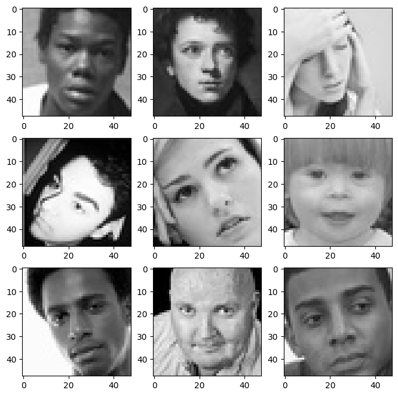

```python
print_expression('neutral')
```

**Observations and Insights:** Although the data is varied, some expressions might be subtle but not entirely neutral. The first two images could be interpreted as boredom and confusion. These being more subtle qualities, we can narrow the neutral expression to a closed or semi-closed mouth in a horizontal position. The eyebrows lack curves, and the eyes are open normally. The lines of expression are minimal.

### **Surprised**

[figure not shown]

```python
print_expression('surprise')
```

**Observations and Insights:** The surprise expression can be narrowed to a wide-open mouth in most cases. We also have wide-open eyes as a regular feature. The curve of the eyebrows is also high and wide. The nasal fossae are also open.

**DATA EXPLORATION** Durin data exploration we found images that are not faces or corrupt files, this files can affect greatly our model performance, lets locate them and remove them form our models.

```python
invalid_images = {'test/happy/15838.jpg',
'train/happy/16540.jpg',
'train/sad/30705.jpg',
'train/sad/35632.jpg',
'train/sad/23894.jpg',
'train/sad/23596.jpg',
'train/surprise/2059.jpg',
'train/surprise/2809.jpg',
'train/surprise/3262.jpg',
'train/surprise/5722.jpg',
'train/surprise/5881.jpg',
'train/surprise/13988.jpg',
'train/surprise/19238.jpg',
'train/surprise/20712.jpg',
'validation/happy/30981.jpg',
'validation/neutral/32683.jpg',
'validation/surprise/35121.jpg'}

Invalid_paths = [os.path.join(folder_path, f) for f in invalid_images]

!mkdir /content/Facial_emotion_images/corrupt

for f in Invalid_paths:
  !mv {f} /content/Facial_emotion_images/corrupt
```

## **Checking Distribution of Classes**

```python
# Distribution of images in train dataset
num_happy = len(os.listdir(folder_path + 'train/happy'))
num_sad = len(os.listdir(folder_path + 'train/sad'))
num_surprise = len(os.listdir(folder_path + 'train/surprise'))
num_neutral = len(os.listdir(folder_path + 'train/neutral'))
print("Happy images: ", num_happy)
print("Sad images: ", num_sad)
print("Surprise images: ", num_surprise)
print("Neutral images: ", num_neutral)
```

```
Happy images:  3975
Sad images:  3978
Surprise images:  3165
Neutral images:  3978
```

```python
# Distribution of images in test dataset
num_happy = len(os.listdir(folder_path + 'test/happy'))
num_sad = len(os.listdir(folder_path + 'test/sad'))
num_surprise = len(os.listdir(folder_path + 'test/surprise'))
num_neutral = len(os.listdir(folder_path + 'test/neutral'))
print("Happy images: ", num_happy)
print("Sad images: ", num_sad)
print("Surprise images: ", num_surprise)
print("Neutral images: ", num_neutral)
```

```
Happy images:  31
Sad images:  32
Surprise images:  32
Neutral images:  32
```

**Observations and Insights:** The difference between the train and test dataset is huge. We also do not have sufficient images for proper neural network training. We mostly have 3,900 images per class, except for the surprise images, which have 800 fewer. Given that we have little data, this difference is important, and the data is not well distributed. We will have issues if we try to progress, as the data is limited and unevenly distributed.

We can try to increase the surprise class with different methods. Data augmentation might help us.

**Think About It:**

- Are the classes equally distributed? If not, do you think the imbalance is too high? Will it be a problem as we progress?

Classes are not evenly distributed, and the imbalance is significant. We will proceed with data augmentation.

- Are there any Exploratory Data Analysis tasks that we can do here? Would they provide any meaningful insights? We looked directly at the files and their count. Now, let's work on data augmentation.

```python
# Load tensorflow datasets
train_dr = '/content/Facial_emotion_images/train/'
test_dr = '/content/Facial_emotion_images/test/'
```

## **Creating our Data Loaders**

In this section, we are creating data loaders that we will use as inputs to our Neural Network.

**You have two options for the color_mode. You can set it to color_mode = 'rgb' or color_mode = 'grayscale'. You will need to try out both and see for yourself which one gives better performance.**

```python
# Create TensorFlow dataframes in gray scale
gray_train_df = image_dataset_from_directory(train_dr, labels='inferred', label_mode='categorical', color_mode='grayscale', batch_size = 32, image_size= (48,48))
gray_test_df = image_dataset_from_directory(test_dr, labels='inferred', label_mode='categorical', color_mode='grayscale', batch_size = 32, image_size= (48,48))
# Now we create them in RGB
color_train_df = image_dataset_from_directory(train_dr, labels='inferred', label_mode='categorical', color_mode='rgb', batch_size = 32, image_size= (48,48))
color_test_df = image_dataset_from_directory(test_dr, labels='inferred', label_mode='categorical', color_mode='rgb', batch_size = 32, image_size= (48,48))
```

```
Found 15096 files belonging to 4 classes.
Found 127 files belonging to 4 classes.
Found 15096 files belonging to 4 classes.
Found 127 files belonging to 4 classes.
```

```python
# We set the random rotation function outside of the built function
rotation = RandomRotation(0.15)

# Augment Function
def augment(image, label):
  # Randomize Brightness
  image = tf.image.random_brightness(image, max_delta=0.1)
  # Flip images horizontaly
  image = tf.image.random_flip_left_right(image)
  # Utilize rotoation in a small variation
  image = rotation(image)
  # Randomize contrast for sharper or duller images
  image = tf.image.random_contrast(image, lower=0.9, upper=1.1)
  # Cap image limit value for functions like random brightness
  image = tf.clip_by_value(image, 0, 255.0)
  # Normalization
  image = image / 255.0
  # Return
  return image, label

# Test Augment Function
def test_augment(image, label):
  # Cap image limit value
  image = tf.clip_by_value(image, 0, 255.0)
  # Normalize
  image = image / 255.0
  # Return
  return image, label
```

```python
# GRAY

# Map this function to every item, use all CPU cores and let tensor flow choose optimal thread count
gray_train_df = gray_train_df.map(augment, num_parallel_calls=tf.data.AUTOTUNE)
# Prefetch data in the background to avoid idle time on the GPU, let tensor flow choose the optimal number of batches to prefetch based on our system resources.
gray_train_df = gray_train_df.prefetch(tf.data.AUTOTUNE)

# Normalize test data
gray_test_df = gray_test_df.map(test_augment, num_parallel_calls=tf.data.AUTOTUNE)
gray_test_df = gray_test_df.prefetch(tf.data.AUTOTUNE)

# RGB

# Map this function to every item, use all CPU cores and let tensor flow choose optimal thread count
color_train_df = color_train_df.map(augment, num_parallel_calls=tf.data.AUTOTUNE)
# Prefetch data in the background to avoid idle time on the GPU, let tensor flow choose the optimal number of batches to prefetch based on our system resources.
color_train_df = color_train_df.prefetch(tf.data.AUTOTUNE)

# Normalize test data
color_test_df = color_test_df.map(test_augment, num_parallel_calls=tf.data.AUTOTUNE)
color_test_df = color_test_df.prefetch(tf.data.AUTOTUNE)
```

```
(32, 48, 48, 1)
```

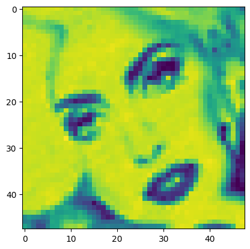

```python
for images, labels in gray_train_df.take(1):
    print(images.shape)  # Verify shapes
    plt.imshow(images[0])  # Visualize
```

## **Model Building**

**Think About It:**

- Are Convolutional Neural Networks the right approach? Convolutional Neural Networks are the right approach. The convolution on 2D works better for images rather than the flattened approach of ANN.
- What are the advantages of CNNs over ANNs and are they applicable here? The CNN give better results on image identification, due to the nature of the layers inside.

### **Creating the Base Neural Network**

```python
# Set random seed
import random
np.random.seed(1)
random.seed(1)
tf.random.set_seed(1)
```

```python
# Create model function
def CNN_model_1(input):
  # Initialize sequential model
  model = Sequential()
  # 1st conv layer, 32 neurons, kernel size (2,2)
  model.add(Conv2D(32, (3,3), padding = 'same', input_shape = (input)))
  # 1st Norm, before activation to normalize activations
  model.add(BatchNormalization())
  # 1st Leaky Relu
  model.add(LeakyReLU(alpha=0.1))
  # 1st Pooling
  model.add(MaxPooling2D(2,2))

  # 2nd Conv layer, 64 neurons
  model.add(Conv2D(64, (3,3), padding = 'same'))
  # 2nd Norm
  model.add(BatchNormalization())
  # 2nd Leaky Relu
  model.add(LeakyReLU(alpha=0.1))
  # 2nd Pooling
  model.add(MaxPooling2D(2,2))

  # 3rd Conv, 32 neurons
  model.add(Conv2D(64, (3,3), padding = 'same'))
    # 3rd Norm
  model.add(BatchNormalization())
  # 3rd Leaky Relu
  model.add(LeakyReLU(alpha=0.1))
  # 3rd Pooling
  model.add(MaxPooling2D(2,2))

  # Flatten
  model.add(Flatten())
  # First dense, 256 Neurons
  model.add(Dense(256))
  # Act. Funct. Leaky Relu
  model.add(LeakyReLU(alpha=0.1))
  # Drop
  model.add(Dropout(0.4))

  # Dense final, output, 4 categories
  model.add(Dense(4, activation = 'softmax'))
  # Optimizer
  opt = Adam(learning_rate=0.0001)
  # Compile
  model.compile(optimizer = opt, loss = 'categorical_crossentropy', metrics = ['accuracy'])
  # Return
  return model
```

### **Compiling and Training the Model**

```python
# Call function and sumary
model_1 = CNN_model_1((48,48,1))
print(model_1.summary())
```

```
Model: "sequential"
```

```
┏━━━━━━━━━━━━━━━━━━━━━━━━━━━━━━━━━┳━━━━━━━━━━━━━━━━━━━━━━━━┳━━━━━━━━━━━━━━━┓
┃ Layer (type)                    ┃ Output Shape           ┃       Param # ┃
┡━━━━━━━━━━━━━━━━━━━━━━━━━━━━━━━━━╇━━━━━━━━━━━━━━━━━━━━━━━━╇━━━━━━━━━━━━━━━┩
│ conv2d (Conv2D)                 │ (None, 48, 48, 32)     │           320 │
├─────────────────────────────────┼────────────────────────┼───────────────┤
│ batch_normalization             │ (None, 48, 48, 32)     │           128 │
│ (BatchNormalization)            │                        │               │
├─────────────────────────────────┼────────────────────────┼───────────────┤
│ leaky_re_lu (LeakyReLU)         │ (None, 48, 48, 32)     │             0 │
├─────────────────────────────────┼────────────────────────┼───────────────┤
│ max_pooling2d (MaxPooling2D)    │ (None, 24, 24, 32)     │             0 │
├─────────────────────────────────┼────────────────────────┼───────────────┤
│ conv2d_1 (Conv2D)               │ (None, 24, 24, 64)     │        18,496 │
├─────────────────────────────────┼────────────────────────┼───────────────┤
│ batch_normalization_1           │ (None, 24, 24, 64)     │           256 │
│ (BatchNormalization)            │                        │               │
├─────────────────────────────────┼────────────────────────┼───────────────┤
│ leaky_re_lu_1 (LeakyReLU)       │ (None, 24, 24, 64)     │             0 │
├─────────────────────────────────┼────────────────────────┼───────────────┤
│ max_pooling2d_1 (MaxPooling2D)  │ (None, 12, 12, 64)     │             0 │
├─────────────────────────────────┼────────────────────────┼───────────────┤
│ conv2d_2 (Conv2D)               │ (None, 12, 12, 64)     │        36,928 │
├─────────────────────────────────┼────────────────────────┼───────────────┤
│ batch_normalization_2           │ (None, 12, 12, 64)     │           256 │
│ (BatchNormalization)            │                        │               │
├─────────────────────────────────┼────────────────────────┼───────────────┤
│ leaky_re_lu_2 (LeakyReLU)       │ (None, 12, 12, 64)     │             0 │
├─────────────────────────────────┼────────────────────────┼───────────────┤
│ max_pooling2d_2 (MaxPooling2D)  │ (None, 6, 6, 64)       │             0 │
├─────────────────────────────────┼────────────────────────┼───────────────┤
│ flatten (Flatten)               │ (None, 2304)           │             0 │
├─────────────────────────────────┼────────────────────────┼───────────────┤
│ dense (Dense)                   │ (None, 256)            │       590,080 │
├─────────────────────────────────┼────────────────────────┼───────────────┤
│ leaky_re_lu_3 (LeakyReLU)       │ (None, 256)            │             0 │
├─────────────────────────────────┼────────────────────────┼───────────────┤
│ dropout (Dropout)               │ (None, 256)            │             0 │
├─────────────────────────────────┼────────────────────────┼───────────────┤
│ dense_1 (Dense)                 │ (None, 4)              │         1,028 │
└─────────────────────────────────┴────────────────────────┴───────────────┘
```

```
 Total params: 647,492 (2.47 MB)
```

```
 Trainable params: 647,172 (2.47 MB)
```

```
 Non-trainable params: 320 (1.25 KB)
```

```
None
```

```python
# Introduce callbacks to improve training
# Save checkpoint in best values
checkpoint = ModelCheckpoint("./model1.h5", monitor='val_acc', verbose=1, save_best_only=True, mode='max')

# Stop when the improvement is low
early_stopping = EarlyStopping(monitor = 'val_loss',
                          min_delta = 0,
                          patience = 4,
                          verbose = 1,
                          restore_best_weights = True
                          )
# Reduce learning rate when validation loss flattens
reduce_learningrate = ReduceLROnPlateau(monitor = 'val_loss',
                              factor = .4,
                              patience = 3,
                              verbose = 1,
                              min_delta = 0.0001)

callbacks_list = [early_stopping, checkpoint, reduce_learningrate]
```

```python
# Fit model
history1 = model_1.fit(gray_train_df, validation_data = gray_test_df, batch_size = 32, verbose = 1, epochs = 20, callbacks = callbacks_list)
```

```
472/472 ━━━━━━━━━━━━━━━━━━━━ 16s 19ms/step - accuracy: 0.3271 - loss: 1.5109 - val_accuracy: 0.3465 - val_loss: 1.4227 - learning_rate: 1.0000e-04
472/472 ━━━━━━━━━━━━━━━━━━━━ 4s 8ms/step - accuracy: 0.4068 - loss: 1.2717 - val_accuracy: 0.5433 - val_loss: 1.1055 - learning_rate: 1.0000e-04
472/472 ━━━━━━━━━━━━━━━━━━━━ 5s 10ms/step - accuracy: 0.4513 - loss: 1.2109 - val_accuracy: 0.5039 - val_loss: 1.0772 - learning_rate: 1.0000e-04
472/472 ━━━━━━━━━━━━━━━━━━━━ 4s 9ms/step - accuracy: 0.4913 - loss: 1.1550 - val_accuracy: 0.5118 - val_loss: 1.0274 - learning_rate: 1.0000e-04
472/472 ━━━━━━━━━━━━━━━━━━━━ 4s 8ms/step - accuracy: 0.5089 - loss: 1.1207 - val_accuracy: 0.5591 - val_loss: 0.9916 - learning_rate: 1.0000e-04
472/472 ━━━━━━━━━━━━━━━━━━━━ 5s 11ms/step - accuracy: 0.5317 - loss: 1.0779 - val_accuracy: 0.5512 - val_loss: 0.8882 - learning_rate: 1.0000e-04
472/472 ━━━━━━━━━━━━━━━━━━━━ 9s 8ms/step - accuracy: 0.5468 - loss: 1.0465 - val_accuracy: 0.5984 - val_loss: 0.8743 - learning_rate: 1.0000e-04
472/472 ━━━━━━━━━━━━━━━━━━━━ 5s 11ms/step - accuracy: 0.5600 - loss: 1.0233 - val_accuracy: 0.6063 - val_loss: 0.8800 - learning_rate: 1.0000e-04
472/472 ━━━━━━━━━━━━━━━━━━━━ 9s 8ms/step - accuracy: 0.5686 - loss: 1.0074 - val_accuracy: 0.6220 - val_loss: 0.8435 - learning_rate: 1.0000e-04
472/472 ━━━━━━━━━━━━━━━━━━━━ 6s 9ms/step - accuracy: 0.5723 - loss: 1.0014 - val_accuracy: 0.6063 - val_loss: 0.8988 - learning_rate: 1.0000e-04
472/472 ━━━━━━━━━━━━━━━━━━━━ 4s 8ms/step - accuracy: 0.5871 - loss: 0.9678 - val_accuracy: 0.6378 - val_loss: 0.8041 - learning_rate: 1.0000e-04
472/472 ━━━━━━━━━━━━━━━━━━━━ 7s 11ms/step - accuracy: 0.5917 - loss: 0.9586 - val_accuracy: 0.6457 - val_loss: 0.7928 - learning_rate: 1.0000e-04
472/472 ━━━━━━━━━━━━━━━━━━━━ 9s 7ms/step - accuracy: 0.5981 - loss: 0.9405 - val_accuracy: 0.6063 - val_loss: 0.8716 - learning_rate: 1.0000e-04
472/472 ━━━━━━━━━━━━━━━━━━━━ 6s 10ms/step - accuracy: 0.6076 - loss: 0.9307 - val_accuracy: 0.6220 - val_loss: 0.8010 - learning_rate: 1.0000e-04
472/472 ━━━━━━━━━━━━━━━━━━━━ 4s 8ms/step - accuracy: 0.6142 - loss: 0.9131 - val_accuracy: 0.6378 - val_loss: 0.7751 - learning_rate: 1.0000e-04
472/472 ━━━━━━━━━━━━━━━━━━━━ 8s 13ms/step - accuracy: 0.6238 - loss: 0.8955 - val_accuracy: 0.6929 - val_loss: 0.7419 - learning_rate: 1.0000e-04
472/472 ━━━━━━━━━━━━━━━━━━━━ 4s 8ms/step - accuracy: 0.6310 - loss: 0.8976 - val_accuracy: 0.6457 - val_loss: 0.7871 - learning_rate: 1.0000e-04
472/472 ━━━━━━━━━━━━━━━━━━━━ 4s 8ms/step - accuracy: 0.6330 - loss: 0.8867 - val_accuracy: 0.6850 - val_loss: 0.7621 - learning_rate: 1.0000e-04
472/472 ━━━━━━━━━━━━━━━━━━━━ 7s 11ms/step - accuracy: 0.6300 - loss: 0.8740 - val_accuracy: 0.7087 - val_loss: 0.7131 - learning_rate: 1.0000e-04
472/472 ━━━━━━━━━━━━━━━━━━━━ 9s 8ms/step - accuracy: 0.6347 - loss: 0.8742 - val_accuracy: 0.6299 - val_loss: 0.8027 - learning_rate: 1.0000e-04
Restoring model weights from the end of the best epoch: 19.
```

### **Evaluating the Model on the Test Set**

```python
# Evaluating on the Test dataset
model_1.evaluate(gray_test_df)
```

```
4/4 ━━━━━━━━━━━━━━━━━━━━ 0s 8ms/step - accuracy: 0.6960 - loss: 0.7438
```

```
[0.713142454624176, 0.7086614370346069]
```

```python
# Define function for plotting
def plot(history):
  plt.plot(history.history['accuracy'])
  plt.plot(history.history['val_accuracy'])
  plt.title('Model Accuracy')
  plt.ylabel('Accuracy')
  plt.xlabel('Epoch')
  plt.legend(['Train', 'Validation'], loc='upper left')
  plt.show()
```

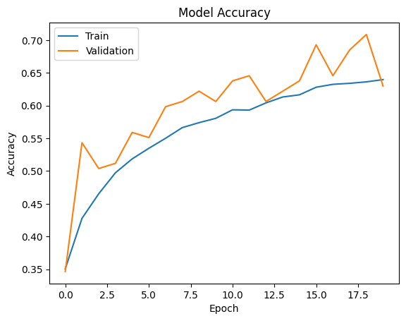

```python
plot(history1)
```

```python
# Clear history and fix seed
def clear():
  tf.keras.backend.clear_session()
  np.random.seed(1)
  random.seed(1)
  tf.random.set_seed(1)
  gc.collect()
  if tf.config.list_physical_devices('GPU'):
      tf.config.experimental.reset_memory_stats('GPU:0')
```

```python
clear()
```

### **Compiling and Training the Model**

```python
# Call function and Sumary
model_2 = CNN_model_1((48,48,3))
print(model_2.summary())
```

```
Model: "sequential"
```

```
┏━━━━━━━━━━━━━━━━━━━━━━━━━━━━━━━━━┳━━━━━━━━━━━━━━━━━━━━━━━━┳━━━━━━━━━━━━━━━┓
┃ Layer (type)                    ┃ Output Shape           ┃       Param # ┃
┡━━━━━━━━━━━━━━━━━━━━━━━━━━━━━━━━━╇━━━━━━━━━━━━━━━━━━━━━━━━╇━━━━━━━━━━━━━━━┩
│ conv2d (Conv2D)                 │ (None, 48, 48, 32)     │           896 │
├─────────────────────────────────┼────────────────────────┼───────────────┤
│ batch_normalization             │ (None, 48, 48, 32)     │           128 │
│ (BatchNormalization)            │                        │               │
├─────────────────────────────────┼────────────────────────┼───────────────┤
│ leaky_re_lu (LeakyReLU)         │ (None, 48, 48, 32)     │             0 │
├─────────────────────────────────┼────────────────────────┼───────────────┤
│ max_pooling2d (MaxPooling2D)    │ (None, 24, 24, 32)     │             0 │
├─────────────────────────────────┼────────────────────────┼───────────────┤
│ conv2d_1 (Conv2D)               │ (None, 24, 24, 64)     │        18,496 │
├─────────────────────────────────┼────────────────────────┼───────────────┤
│ batch_normalization_1           │ (None, 24, 24, 64)     │           256 │
│ (BatchNormalization)            │                        │               │
├─────────────────────────────────┼────────────────────────┼───────────────┤
│ leaky_re_lu_1 (LeakyReLU)       │ (None, 24, 24, 64)     │             0 │
├─────────────────────────────────┼────────────────────────┼───────────────┤
│ max_pooling2d_1 (MaxPooling2D)  │ (None, 12, 12, 64)     │             0 │
├─────────────────────────────────┼────────────────────────┼───────────────┤
│ conv2d_2 (Conv2D)               │ (None, 12, 12, 64)     │        36,928 │
├─────────────────────────────────┼────────────────────────┼───────────────┤
│ batch_normalization_2           │ (None, 12, 12, 64)     │           256 │
│ (BatchNormalization)            │                        │               │
├─────────────────────────────────┼────────────────────────┼───────────────┤
│ leaky_re_lu_2 (LeakyReLU)       │ (None, 12, 12, 64)     │             0 │
├─────────────────────────────────┼────────────────────────┼───────────────┤
│ max_pooling2d_2 (MaxPooling2D)  │ (None, 6, 6, 64)       │             0 │
├─────────────────────────────────┼────────────────────────┼───────────────┤
│ flatten (Flatten)               │ (None, 2304)           │             0 │
├─────────────────────────────────┼────────────────────────┼───────────────┤
│ dense (Dense)                   │ (None, 256)            │       590,080 │
├─────────────────────────────────┼────────────────────────┼───────────────┤
│ leaky_re_lu_3 (LeakyReLU)       │ (None, 256)            │             0 │
├─────────────────────────────────┼────────────────────────┼───────────────┤
│ dropout (Dropout)               │ (None, 256)            │             0 │
├─────────────────────────────────┼────────────────────────┼───────────────┤
│ dense_1 (Dense)                 │ (None, 4)              │         1,028 │
└─────────────────────────────────┴────────────────────────┴───────────────┘
```

```
 Total params: 648,068 (2.47 MB)
```

```
 Trainable params: 647,748 (2.47 MB)
```

```
 Non-trainable params: 320 (1.25 KB)
```

```
None
```

```python
# Introduce callbacks to improve training
# Save checkpoint in best values
checkpoint = ModelCheckpoint("./model2.h5", monitor='val_acc', verbose=1, save_best_only=True, mode='max')


# Stop when the improvement is low
early_stopping = EarlyStopping(monitor = 'val_loss',
                          min_delta = 0.00001,     # Changing factors to see behaviour in model
                          patience = 3,
                          verbose = 1,
                          restore_best_weights = True
                          )
# Reduce learning rate when validation loss flattens
reduce_learningrate = ReduceLROnPlateau(monitor = 'val_loss',
                              factor = 0.4,     # Changing factors to see behaviour in model
                              patience = 3,
                              verbose = 1,
                              min_delta = 0.0005) # Changing factors to see behaviour in model

callbacks_list = [early_stopping, checkpoint, reduce_learningrate]
```

```python
# Fit model
history2 = model_2.fit(color_train_df, validation_data = color_test_df, batch_size = 32, verbose = 1, epochs = 20, callbacks = callbacks_list)
```

```
472/472 ━━━━━━━━━━━━━━━━━━━━ 16s 18ms/step - accuracy: 0.3251 - loss: 1.4894 - val_accuracy: 0.3937 - val_loss: 1.2678 - learning_rate: 1.0000e-04
472/472 ━━━━━━━━━━━━━━━━━━━━ 6s 13ms/step - accuracy: 0.4005 - loss: 1.2818 - val_accuracy: 0.5197 - val_loss: 1.1585 - learning_rate: 1.0000e-04
472/472 ━━━━━━━━━━━━━━━━━━━━ 10s 14ms/step - accuracy: 0.4421 - loss: 1.2095 - val_accuracy: 0.5118 - val_loss: 1.0655 - learning_rate: 1.0000e-04
472/472 ━━━━━━━━━━━━━━━━━━━━ 5s 11ms/step - accuracy: 0.4674 - loss: 1.1696 - val_accuracy: 0.5827 - val_loss: 0.9713 - learning_rate: 1.0000e-04
472/472 ━━━━━━━━━━━━━━━━━━━━ 11s 13ms/step - accuracy: 0.5012 - loss: 1.1255 - val_accuracy: 0.5354 - val_loss: 0.9874 - learning_rate: 1.0000e-04
472/472 ━━━━━━━━━━━━━━━━━━━━ 5s 11ms/step - accuracy: 0.5234 - loss: 1.0924 - val_accuracy: 0.5118 - val_loss: 0.9541 - learning_rate: 1.0000e-04
472/472 ━━━━━━━━━━━━━━━━━━━━ 7s 14ms/step - accuracy: 0.5360 - loss: 1.0802 - val_accuracy: 0.5906 - val_loss: 0.8825 - learning_rate: 1.0000e-04
472/472 ━━━━━━━━━━━━━━━━━━━━ 9s 11ms/step - accuracy: 0.5471 - loss: 1.0453 - val_accuracy: 0.5906 - val_loss: 0.8544 - learning_rate: 1.0000e-04
472/472 ━━━━━━━━━━━━━━━━━━━━ 6s 13ms/step - accuracy: 0.5630 - loss: 1.0239 - val_accuracy: 0.5906 - val_loss: 0.8833 - learning_rate: 1.0000e-04
472/472 ━━━━━━━━━━━━━━━━━━━━ 5s 11ms/step - accuracy: 0.5630 - loss: 1.0139 - val_accuracy: 0.5591 - val_loss: 0.9126 - learning_rate: 1.0000e-04
472/472 ━━━━━━━━━━━━━━━━━━━━ 10s 11ms/step - accuracy: 0.5764 - loss: 0.9966 - val_accuracy: 0.6063 - val_loss: 0.8182 - learning_rate: 1.0000e-04
472/472 ━━━━━━━━━━━━━━━━━━━━ 10s 11ms/step - accuracy: 0.5850 - loss: 0.9718 - val_accuracy: 0.6378 - val_loss: 0.8618 - learning_rate: 1.0000e-04
472/472 ━━━━━━━━━━━━━━━━━━━━ 5s 11ms/step - accuracy: 0.5915 - loss: 0.9609 - val_accuracy: 0.6378 - val_loss: 0.8729 - learning_rate: 1.0000e-04
472/472 ━━━━━━━━━━━━━━━━━━━━ 10s 11ms/step - accuracy: 0.6008 - loss: 0.9429 - val_accuracy: 0.6378 - val_loss: 0.8026 - learning_rate: 1.0000e-04
472/472 ━━━━━━━━━━━━━━━━━━━━ 7s 14ms/step - accuracy: 0.6130 - loss: 0.9248 - val_accuracy: 0.6220 - val_loss: 0.8714 - learning_rate: 1.0000e-04
472/472 ━━━━━━━━━━━━━━━━━━━━ 9s 11ms/step - accuracy: 0.6127 - loss: 0.9292 - val_accuracy: 0.6378 - val_loss: 0.7927 - learning_rate: 1.0000e-04
472/472 ━━━━━━━━━━━━━━━━━━━━ 7s 14ms/step - accuracy: 0.6129 - loss: 0.9237 - val_accuracy: 0.6457 - val_loss: 0.7392 - learning_rate: 1.0000e-04
472/472 ━━━━━━━━━━━━━━━━━━━━ 10s 14ms/step - accuracy: 0.6203 - loss: 0.8953 - val_accuracy: 0.6614 - val_loss: 0.7464 - learning_rate: 1.0000e-04
472/472 ━━━━━━━━━━━━━━━━━━━━ 11s 14ms/step - accuracy: 0.6307 - loss: 0.8925 - val_accuracy: 0.6772 - val_loss: 0.7551 - learning_rate: 1.0000e-04
468/472 ━━━━━━━━━━━━━━━━━━━━ 0s 11ms/step - accuracy: 0.6309 - loss: 0.8831
Epoch 20: ReduceLROnPlateau reducing learning rate to 3.9999998989515007e-05.
472/472 ━━━━━━━━━━━━━━━━━━━━ 8s 11ms/step - accuracy: 0.6309 - loss: 0.8831 - val_accuracy: 0.6457 - val_loss: 0.7617 - learning_rate: 1.0000e-04
Epoch 20: early stopping
Restoring model weights from the end of the best epoch: 17.
```

### **Evaluating the Model on the Test Set**

```python
# Evaluating on the Test dataset
model_2.evaluate(color_test_df)
```

```
4/4 ━━━━━━━━━━━━━━━━━━━━ 0s 9ms/step - accuracy: 0.6718 - loss: 0.7173
```

```
[0.7391769289970398, 0.6456692814826965]
```

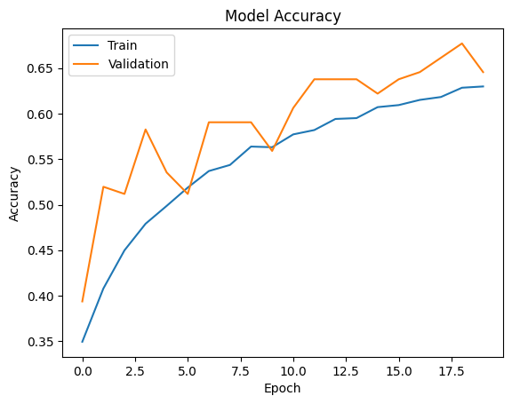

```python
# Plot
plot(history2)
```

```python
# Clear history and fix seed
clear()
```

### **Creating the second Convolutional Neural Network**

- Try out a slightly larger architecture

```python
# Create model function
def CNN_model_2(input):
  # Initialize sequential model
  model = Sequential()
  # 1st conv layer, 64 neurons, kernel size (2,2)
  model.add(Conv2D(64, (3,3), padding = 'same', input_shape = (input)))
  # 1st Norm, before activation to normalize activations
  model.add(BatchNormalization())
  # 1st Leaky Relu
  model.add(LeakyReLU(alpha=0.1))
  # 1st Pooling
  model.add(MaxPooling2D(2,2))

  # 2nd Conv layer, 128 neurons
  model.add(Conv2D(128, (3,3), padding = 'same'))
  # 2nd Norm
  model.add(BatchNormalization())
  # 2nd Leaky Relu
  model.add(LeakyReLU(alpha=0.1))
  # 2nd Pooling
  model.add(MaxPooling2D(2,2))

  # 3rd Conv, 256 neurons
  model.add(Conv2D(256, (3,3), padding = 'same'))
    # 3rd Norm
  model.add(BatchNormalization())
  # 3rd Leaky Relu
  model.add(LeakyReLU(alpha=0.1))
  # 3rd Pooling
  model.add(MaxPooling2D(2,2))

  # 4th Conv, 512 neurons
  model.add(Conv2D(512, (3,3), padding = 'same'))
  # 4th Norm
  model.add(BatchNormalization())
  # 4th Leaky Relu
  model.add(LeakyReLU(alpha=0.1))
  # 4th Pooling
  model.add(MaxPooling2D(2,2))
  # Drop
  model.add(Dropout(0.2))

  # Flatten
  model.add(Flatten())
  # First dense, 512 Neurons
  model.add(Dense(512))
  # Act. Funct. Leaky Relu
  model.add(LeakyReLU(alpha=0.1))
  # Drop
  model.add(Dropout(0.4))

  # 2nd Dense layer, 128 neurons
  model.add(Dense(128))
  # Act. Funct. Leaky Relu
  model.add(LeakyReLU(alpha=0.1))
  # Drop
  model.add(Dropout(0.2))

  # Dense final, output, 4 categories
  model.add(Dense(4, activation = 'softmax'))
  # Optimizer
  opt = Adam(learning_rate=0.0003)
  # Compile
  model.compile(optimizer = opt, loss = 'categorical_crossentropy', metrics = ['accuracy'])
  # Return
  return model
```

### **Compiling and Training the Model**

```python
# Sumary
model_3 = CNN_model_2((48,48,1))
print(model_3.summary())
```

```
Model: "sequential"
```

```
┏━━━━━━━━━━━━━━━━━━━━━━━━━━━━━━━━━┳━━━━━━━━━━━━━━━━━━━━━━━━┳━━━━━━━━━━━━━━━┓
┃ Layer (type)                    ┃ Output Shape           ┃       Param # ┃
┡━━━━━━━━━━━━━━━━━━━━━━━━━━━━━━━━━╇━━━━━━━━━━━━━━━━━━━━━━━━╇━━━━━━━━━━━━━━━┩
│ conv2d (Conv2D)                 │ (None, 48, 48, 64)     │           640 │
├─────────────────────────────────┼────────────────────────┼───────────────┤
│ batch_normalization             │ (None, 48, 48, 64)     │           256 │
│ (BatchNormalization)            │                        │               │
├─────────────────────────────────┼────────────────────────┼───────────────┤
│ leaky_re_lu (LeakyReLU)         │ (None, 48, 48, 64)     │             0 │
├─────────────────────────────────┼────────────────────────┼───────────────┤
│ max_pooling2d (MaxPooling2D)    │ (None, 24, 24, 64)     │             0 │
├─────────────────────────────────┼────────────────────────┼───────────────┤
│ conv2d_1 (Conv2D)               │ (None, 24, 24, 128)    │        73,856 │
├─────────────────────────────────┼────────────────────────┼───────────────┤
│ batch_normalization_1           │ (None, 24, 24, 128)    │           512 │
│ (BatchNormalization)            │                        │               │
├─────────────────────────────────┼────────────────────────┼───────────────┤
│ leaky_re_lu_1 (LeakyReLU)       │ (None, 24, 24, 128)    │             0 │
├─────────────────────────────────┼────────────────────────┼───────────────┤
│ max_pooling2d_1 (MaxPooling2D)  │ (None, 12, 12, 128)    │             0 │
├─────────────────────────────────┼────────────────────────┼───────────────┤
│ conv2d_2 (Conv2D)               │ (None, 12, 12, 256)    │       295,168 │
├─────────────────────────────────┼────────────────────────┼───────────────┤
│ batch_normalization_2           │ (None, 12, 12, 256)    │         1,024 │
│ (BatchNormalization)            │                        │               │
├─────────────────────────────────┼────────────────────────┼───────────────┤
│ leaky_re_lu_2 (LeakyReLU)       │ (None, 12, 12, 256)    │             0 │
├─────────────────────────────────┼────────────────────────┼───────────────┤
│ max_pooling2d_2 (MaxPooling2D)  │ (None, 6, 6, 256)      │             0 │
├─────────────────────────────────┼────────────────────────┼───────────────┤
│ conv2d_3 (Conv2D)               │ (None, 6, 6, 512)      │     1,180,160 │
├─────────────────────────────────┼────────────────────────┼───────────────┤
│ batch_normalization_3           │ (None, 6, 6, 512)      │         2,048 │
│ (BatchNormalization)            │                        │               │
├─────────────────────────────────┼────────────────────────┼───────────────┤
│ leaky_re_lu_3 (LeakyReLU)       │ (None, 6, 6, 512)      │             0 │
├─────────────────────────────────┼────────────────────────┼───────────────┤
│ max_pooling2d_3 (MaxPooling2D)  │ (None, 3, 3, 512)      │             0 │
├─────────────────────────────────┼────────────────────────┼───────────────┤
│ dropout (Dropout)               │ (None, 3, 3, 512)      │             0 │
├─────────────────────────────────┼────────────────────────┼───────────────┤
│ flatten (Flatten)               │ (None, 4608)           │             0 │
├─────────────────────────────────┼────────────────────────┼───────────────┤
│ dense (Dense)                   │ (None, 512)            │     2,359,808 │
├─────────────────────────────────┼────────────────────────┼───────────────┤
│ leaky_re_lu_4 (LeakyReLU)       │ (None, 512)            │             0 │
├─────────────────────────────────┼────────────────────────┼───────────────┤
│ dropout_1 (Dropout)             │ (None, 512)            │             0 │
├─────────────────────────────────┼────────────────────────┼───────────────┤
│ dense_1 (Dense)                 │ (None, 128)            │        65,664 │
├─────────────────────────────────┼────────────────────────┼───────────────┤
│ leaky_re_lu_5 (LeakyReLU)       │ (None, 128)            │             0 │
├─────────────────────────────────┼────────────────────────┼───────────────┤
│ dropout_2 (Dropout)             │ (None, 128)            │             0 │
├─────────────────────────────────┼────────────────────────┼───────────────┤
│ dense_2 (Dense)                 │ (None, 4)              │           516 │
└─────────────────────────────────┴────────────────────────┴───────────────┘
```

```
 Total params: 3,979,652 (15.18 MB)
```

```
 Trainable params: 3,977,732 (15.17 MB)
```

```
 Non-trainable params: 1,920 (7.50 KB)
```

```
None
```

```python
# Introduce callbacks to improve training
# Save checkpoint in best values
checkpoint = ModelCheckpoint("./model3.h5", monitor='val_acc', verbose=1, save_best_only=True, mode='max')


# Stop when the improvement is low
early_stopping = EarlyStopping(monitor = 'val_loss',
                          min_delta = 0.00005,     # Changing factors to see behaviour in model
                          patience = 8,
                          verbose = 1,
                          restore_best_weights = True
                          )
# Reduce learning rate when validation loss flattens
reduce_learningrate = ReduceLROnPlateau(monitor = 'val_loss',
                              factor = 0.4,     # Changing factors to see behaviour in model
                              patience = 3,
                              verbose = 1,
                              min_delta = 0.0001) # Changing factors to see behaviour in model

callbacks_list = [early_stopping, checkpoint, reduce_learningrate]
```

```python
# Fit model
history3 = model_3.fit(gray_train_df, validation_data = gray_test_df, batch_size = 32, verbose = 1, epochs = 20, callbacks = callbacks_list)
```

```
472/472 ━━━━━━━━━━━━━━━━━━━━ 23s 28ms/step - accuracy: 0.3117 - loss: 1.6173 - val_accuracy: 0.2756 - val_loss: 1.5712 - learning_rate: 3.0000e-04
472/472 ━━━━━━━━━━━━━━━━━━━━ 6s 13ms/step - accuracy: 0.3681 - loss: 1.3006 - val_accuracy: 0.4961 - val_loss: 1.1029 - learning_rate: 3.0000e-04
472/472 ━━━━━━━━━━━━━━━━━━━━ 10s 13ms/step - accuracy: 0.4356 - loss: 1.2185 - val_accuracy: 0.5669 - val_loss: 0.9480 - learning_rate: 3.0000e-04
472/472 ━━━━━━━━━━━━━━━━━━━━ 11s 14ms/step - accuracy: 0.5013 - loss: 1.1063 - val_accuracy: 0.5039 - val_loss: 1.0076 - learning_rate: 3.0000e-04
472/472 ━━━━━━━━━━━━━━━━━━━━ 11s 15ms/step - accuracy: 0.5567 - loss: 1.0212 - val_accuracy: 0.6457 - val_loss: 0.8573 - learning_rate: 3.0000e-04
472/472 ━━━━━━━━━━━━━━━━━━━━ 6s 13ms/step - accuracy: 0.5899 - loss: 0.9539 - val_accuracy: 0.6063 - val_loss: 0.9855 - learning_rate: 3.0000e-04
472/472 ━━━━━━━━━━━━━━━━━━━━ 10s 13ms/step - accuracy: 0.6074 - loss: 0.9149 - val_accuracy: 0.5827 - val_loss: 1.0432 - learning_rate: 3.0000e-04
470/472 ━━━━━━━━━━━━━━━━━━━━ 0s 15ms/step - accuracy: 0.6154 - loss: 0.8876
Epoch 8: ReduceLROnPlateau reducing learning rate to 0.00012000000569969416.
472/472 ━━━━━━━━━━━━━━━━━━━━ 11s 15ms/step - accuracy: 0.6155 - loss: 0.8875 - val_accuracy: 0.6614 - val_loss: 0.8784 - learning_rate: 3.0000e-04
472/472 ━━━━━━━━━━━━━━━━━━━━ 6s 14ms/step - accuracy: 0.6565 - loss: 0.8132 - val_accuracy: 0.7323 - val_loss: 0.6566 - learning_rate: 1.2000e-04
472/472 ━━━━━━━━━━━━━━━━━━━━ 7s 15ms/step - accuracy: 0.6767 - loss: 0.7768 - val_accuracy: 0.7165 - val_loss: 0.6814 - learning_rate: 1.2000e-04
472/472 ━━━━━━━━━━━━━━━━━━━━ 6s 13ms/step - accuracy: 0.6799 - loss: 0.7713 - val_accuracy: 0.7559 - val_loss: 0.6512 - learning_rate: 1.2000e-04
472/472 ━━━━━━━━━━━━━━━━━━━━ 7s 14ms/step - accuracy: 0.6894 - loss: 0.7552 - val_accuracy: 0.7244 - val_loss: 0.6461 - learning_rate: 1.2000e-04
472/472 ━━━━━━━━━━━━━━━━━━━━ 6s 13ms/step - accuracy: 0.6911 - loss: 0.7405 - val_accuracy: 0.7638 - val_loss: 0.6785 - learning_rate: 1.2000e-04
472/472 ━━━━━━━━━━━━━━━━━━━━ 10s 13ms/step - accuracy: 0.6973 - loss: 0.7362 - val_accuracy: 0.7402 - val_loss: 0.6574 - learning_rate: 1.2000e-04
472/472 ━━━━━━━━━━━━━━━━━━━━ 0s 13ms/step - accuracy: 0.7033 - loss: 0.7216
Epoch 15: ReduceLROnPlateau reducing learning rate to 4.8000001697801054e-05.
472/472 ━━━━━━━━━━━━━━━━━━━━ 10s 13ms/step - accuracy: 0.7033 - loss: 0.7216 - val_accuracy: 0.7402 - val_loss: 0.7111 - learning_rate: 1.2000e-04
472/472 ━━━━━━━━━━━━━━━━━━━━ 7s 14ms/step - accuracy: 0.7089 - loss: 0.6941 - val_accuracy: 0.7559 - val_loss: 0.5947 - learning_rate: 4.8000e-05
472/472 ━━━━━━━━━━━━━━━━━━━━ 10s 13ms/step - accuracy: 0.7221 - loss: 0.6772 - val_accuracy: 0.7795 - val_loss: 0.5646 - learning_rate: 4.8000e-05
472/472 ━━━━━━━━━━━━━━━━━━━━ 7s 14ms/step - accuracy: 0.7207 - loss: 0.6732 - val_accuracy: 0.7323 - val_loss: 0.5978 - learning_rate: 4.8000e-05
472/472 ━━━━━━━━━━━━━━━━━━━━ 10s 14ms/step - accuracy: 0.7307 - loss: 0.6691 - val_accuracy: 0.7638 - val_loss: 0.5979 - learning_rate: 4.8000e-05
468/472 ━━━━━━━━━━━━━━━━━━━━ 0s 14ms/step - accuracy: 0.7250 - loss: 0.6698
Epoch 20: ReduceLROnPlateau reducing learning rate to 1.920000067912042e-05.
472/472 ━━━━━━━━━━━━━━━━━━━━ 10s 15ms/step - accuracy: 0.7251 - loss: 0.6697 - val_accuracy: 0.7717 - val_loss: 0.6229 - learning_rate: 4.8000e-05
Restoring model weights from the end of the best epoch: 17.
```

### **Evaluating the Model on the Test Set**

```python
# Evaluating on the Test dataset
model_3.evaluate(gray_test_df)
```

```
4/4 ━━━━━━━━━━━━━━━━━━━━ 0s 11ms/step - accuracy: 0.7889 - loss: 0.5346
```

```
[0.5645937919616699, 0.7795275449752808]
```

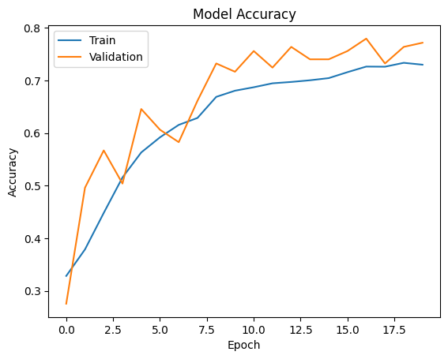

```python
# Plot
plot(history3)
```

```python
# Clear
clear()
```

### **Compiling and Training the Model**

```python
# Sumary
model_4 = CNN_model_2((48,48,3))
print(model_4.summary())
```

```
Model: "sequential"
```

```
┏━━━━━━━━━━━━━━━━━━━━━━━━━━━━━━━━━┳━━━━━━━━━━━━━━━━━━━━━━━━┳━━━━━━━━━━━━━━━┓
┃ Layer (type)                    ┃ Output Shape           ┃       Param # ┃
┡━━━━━━━━━━━━━━━━━━━━━━━━━━━━━━━━━╇━━━━━━━━━━━━━━━━━━━━━━━━╇━━━━━━━━━━━━━━━┩
│ conv2d (Conv2D)                 │ (None, 48, 48, 64)     │         1,792 │
├─────────────────────────────────┼────────────────────────┼───────────────┤
│ batch_normalization             │ (None, 48, 48, 64)     │           256 │
│ (BatchNormalization)            │                        │               │
├─────────────────────────────────┼────────────────────────┼───────────────┤
│ leaky_re_lu (LeakyReLU)         │ (None, 48, 48, 64)     │             0 │
├─────────────────────────────────┼────────────────────────┼───────────────┤
│ max_pooling2d (MaxPooling2D)    │ (None, 24, 24, 64)     │             0 │
├─────────────────────────────────┼────────────────────────┼───────────────┤
│ conv2d_1 (Conv2D)               │ (None, 24, 24, 128)    │        73,856 │
├─────────────────────────────────┼────────────────────────┼───────────────┤
│ batch_normalization_1           │ (None, 24, 24, 128)    │           512 │
│ (BatchNormalization)            │                        │               │
├─────────────────────────────────┼────────────────────────┼───────────────┤
│ leaky_re_lu_1 (LeakyReLU)       │ (None, 24, 24, 128)    │             0 │
├─────────────────────────────────┼────────────────────────┼───────────────┤
│ max_pooling2d_1 (MaxPooling2D)  │ (None, 12, 12, 128)    │             0 │
├─────────────────────────────────┼────────────────────────┼───────────────┤
│ conv2d_2 (Conv2D)               │ (None, 12, 12, 256)    │       295,168 │
├─────────────────────────────────┼────────────────────────┼───────────────┤
│ batch_normalization_2           │ (None, 12, 12, 256)    │         1,024 │
│ (BatchNormalization)            │                        │               │
├─────────────────────────────────┼────────────────────────┼───────────────┤
│ leaky_re_lu_2 (LeakyReLU)       │ (None, 12, 12, 256)    │             0 │
├─────────────────────────────────┼────────────────────────┼───────────────┤
│ max_pooling2d_2 (MaxPooling2D)  │ (None, 6, 6, 256)      │             0 │
├─────────────────────────────────┼────────────────────────┼───────────────┤
│ conv2d_3 (Conv2D)               │ (None, 6, 6, 512)      │     1,180,160 │
├─────────────────────────────────┼────────────────────────┼───────────────┤
│ batch_normalization_3           │ (None, 6, 6, 512)      │         2,048 │
│ (BatchNormalization)            │                        │               │
├─────────────────────────────────┼────────────────────────┼───────────────┤
│ leaky_re_lu_3 (LeakyReLU)       │ (None, 6, 6, 512)      │             0 │
├─────────────────────────────────┼────────────────────────┼───────────────┤
│ max_pooling2d_3 (MaxPooling2D)  │ (None, 3, 3, 512)      │             0 │
├─────────────────────────────────┼────────────────────────┼───────────────┤
│ dropout (Dropout)               │ (None, 3, 3, 512)      │             0 │
├─────────────────────────────────┼────────────────────────┼───────────────┤
│ flatten (Flatten)               │ (None, 4608)           │             0 │
├─────────────────────────────────┼────────────────────────┼───────────────┤
│ dense (Dense)                   │ (None, 512)            │     2,359,808 │
├─────────────────────────────────┼────────────────────────┼───────────────┤
│ leaky_re_lu_4 (LeakyReLU)       │ (None, 512)            │             0 │
├─────────────────────────────────┼────────────────────────┼───────────────┤
│ dropout_1 (Dropout)             │ (None, 512)            │             0 │
├─────────────────────────────────┼────────────────────────┼───────────────┤
│ dense_1 (Dense)                 │ (None, 128)            │        65,664 │
├─────────────────────────────────┼────────────────────────┼───────────────┤
│ leaky_re_lu_5 (LeakyReLU)       │ (None, 128)            │             0 │
├─────────────────────────────────┼────────────────────────┼───────────────┤
│ dropout_2 (Dropout)             │ (None, 128)            │             0 │
├─────────────────────────────────┼────────────────────────┼───────────────┤
│ dense_2 (Dense)                 │ (None, 4)              │           516 │
└─────────────────────────────────┴────────────────────────┴───────────────┘
```

```
 Total params: 3,980,804 (15.19 MB)
```

```
 Trainable params: 3,978,884 (15.18 MB)
```

```
 Non-trainable params: 1,920 (7.50 KB)
```

```
None
```

```python
# Introduce callbacks to improve training
# Save checkpoint in best values
checkpoint = ModelCheckpoint("./model4.h5", monitor='val_acc', verbose=1, save_best_only=True, mode='max')


# Stop when the improvement is low
early_stopping = EarlyStopping(monitor = 'val_loss',
                          min_delta = 0.00006,     # Changing factors to see behaviour in model
                          patience = 6,
                          verbose = 1,
                          restore_best_weights = True
                          )
# Reduce learning rate when validation loss flattens
reduce_learningrate = ReduceLROnPlateau(monitor = 'val_loss',
                              factor = 0.4,     # Changing factors to see behaviour in model
                              patience = 4,
                              verbose = 1,
                              min_delta = 0.0001) # Changing factors to see behaviour in model

callbacks_list = [early_stopping, checkpoint, reduce_learningrate]
```

```python
# Fit model
history4 = model_4.fit(color_train_df, validation_data = color_test_df, batch_size = 32, verbose = 1, epochs = 30, callbacks = callbacks_list)
```

```
472/472 ━━━━━━━━━━━━━━━━━━━━ 20s 27ms/step - accuracy: 0.3117 - loss: 1.6040 - val_accuracy: 0.4016 - val_loss: 1.2865 - learning_rate: 3.0000e-04
472/472 ━━━━━━━━━━━━━━━━━━━━ 8s 16ms/step - accuracy: 0.3773 - loss: 1.3014 - val_accuracy: 0.3622 - val_loss: 1.3455 - learning_rate: 3.0000e-04
472/472 ━━━━━━━━━━━━━━━━━━━━ 6s 14ms/step - accuracy: 0.4348 - loss: 1.2127 - val_accuracy: 0.5748 - val_loss: 0.9775 - learning_rate: 3.0000e-04
472/472 ━━━━━━━━━━━━━━━━━━━━ 11s 16ms/step - accuracy: 0.5087 - loss: 1.1018 - val_accuracy: 0.5906 - val_loss: 0.9355 - learning_rate: 3.0000e-04
472/472 ━━━━━━━━━━━━━━━━━━━━ 10s 16ms/step - accuracy: 0.5538 - loss: 1.0278 - val_accuracy: 0.5827 - val_loss: 0.9145 - learning_rate: 3.0000e-04
472/472 ━━━━━━━━━━━━━━━━━━━━ 9s 14ms/step - accuracy: 0.5864 - loss: 0.9712 - val_accuracy: 0.5906 - val_loss: 0.9582 - learning_rate: 3.0000e-04
472/472 ━━━━━━━━━━━━━━━━━━━━ 10s 13ms/step - accuracy: 0.6058 - loss: 0.9240 - val_accuracy: 0.5748 - val_loss: 0.8925 - learning_rate: 3.0000e-04
472/472 ━━━━━━━━━━━━━━━━━━━━ 10s 14ms/step - accuracy: 0.6293 - loss: 0.8838 - val_accuracy: 0.6850 - val_loss: 0.7611 - learning_rate: 3.0000e-04
472/472 ━━━━━━━━━━━━━━━━━━━━ 8s 16ms/step - accuracy: 0.6437 - loss: 0.8626 - val_accuracy: 0.6299 - val_loss: 0.8550 - learning_rate: 3.0000e-04
472/472 ━━━━━━━━━━━━━━━━━━━━ 7s 14ms/step - accuracy: 0.6521 - loss: 0.8344 - val_accuracy: 0.6772 - val_loss: 0.7222 - learning_rate: 3.0000e-04
472/472 ━━━━━━━━━━━━━━━━━━━━ 11s 15ms/step - accuracy: 0.6610 - loss: 0.8118 - val_accuracy: 0.6772 - val_loss: 0.7577 - learning_rate: 3.0000e-04
472/472 ━━━━━━━━━━━━━━━━━━━━ 7s 16ms/step - accuracy: 0.6732 - loss: 0.7910 - val_accuracy: 0.7165 - val_loss: 0.7740 - learning_rate: 3.0000e-04
472/472 ━━━━━━━━━━━━━━━━━━━━ 7s 14ms/step - accuracy: 0.6824 - loss: 0.7790 - val_accuracy: 0.6299 - val_loss: 1.0284 - learning_rate: 3.0000e-04
470/472 ━━━━━━━━━━━━━━━━━━━━ 0s 16ms/step - accuracy: 0.6860 - loss: 0.7635
Epoch 14: ReduceLROnPlateau reducing learning rate to 0.00012000000569969416.
472/472 ━━━━━━━━━━━━━━━━━━━━ 8s 16ms/step - accuracy: 0.6860 - loss: 0.7634 - val_accuracy: 0.6929 - val_loss: 0.7341 - learning_rate: 3.0000e-04
472/472 ━━━━━━━━━━━━━━━━━━━━ 6s 13ms/step - accuracy: 0.7062 - loss: 0.7236 - val_accuracy: 0.7244 - val_loss: 0.6707 - learning_rate: 1.2000e-04
472/472 ━━━━━━━━━━━━━━━━━━━━ 8s 16ms/step - accuracy: 0.7200 - loss: 0.6854 - val_accuracy: 0.7638 - val_loss: 0.6247 - learning_rate: 1.2000e-04
472/472 ━━━━━━━━━━━━━━━━━━━━ 6s 14ms/step - accuracy: 0.7169 - loss: 0.6872 - val_accuracy: 0.7559 - val_loss: 0.6097 - learning_rate: 1.2000e-04
472/472 ━━━━━━━━━━━━━━━━━━━━ 8s 16ms/step - accuracy: 0.7199 - loss: 0.6822 - val_accuracy: 0.7244 - val_loss: 0.6437 - learning_rate: 1.2000e-04
472/472 ━━━━━━━━━━━━━━━━━━━━ 7s 14ms/step - accuracy: 0.7310 - loss: 0.6684 - val_accuracy: 0.7717 - val_loss: 0.6097 - learning_rate: 1.2000e-04
472/472 ━━━━━━━━━━━━━━━━━━━━ 8s 16ms/step - accuracy: 0.7372 - loss: 0.6611 - val_accuracy: 0.7717 - val_loss: 0.6017 - learning_rate: 1.2000e-04
472/472 ━━━━━━━━━━━━━━━━━━━━ 6s 14ms/step - accuracy: 0.7295 - loss: 0.6688 - val_accuracy: 0.7402 - val_loss: 0.6374 - learning_rate: 1.2000e-04
472/472 ━━━━━━━━━━━━━━━━━━━━ 10s 14ms/step - accuracy: 0.7288 - loss: 0.6577 - val_accuracy: 0.7638 - val_loss: 0.6149 - learning_rate: 1.2000e-04
472/472 ━━━━━━━━━━━━━━━━━━━━ 11s 15ms/step - accuracy: 0.7377 - loss: 0.6363 - val_accuracy: 0.7165 - val_loss: 0.6217 - learning_rate: 1.2000e-04
472/472 ━━━━━━━━━━━━━━━━━━━━ 7s 15ms/step - accuracy: 0.7344 - loss: 0.6415 - val_accuracy: 0.7480 - val_loss: 0.5995 - learning_rate: 1.2000e-04
472/472 ━━━━━━━━━━━━━━━━━━━━ 7s 15ms/step - accuracy: 0.7419 - loss: 0.6334 - val_accuracy: 0.7402 - val_loss: 0.6620 - learning_rate: 1.2000e-04
472/472 ━━━━━━━━━━━━━━━━━━━━ 7s 15ms/step - accuracy: 0.7413 - loss: 0.6247 - val_accuracy: 0.7559 - val_loss: 0.6197 - learning_rate: 1.2000e-04
472/472 ━━━━━━━━━━━━━━━━━━━━ 10s 14ms/step - accuracy: 0.7446 - loss: 0.6241 - val_accuracy: 0.7953 - val_loss: 0.5991 - learning_rate: 1.2000e-04
472/472 ━━━━━━━━━━━━━━━━━━━━ 8s 16ms/step - accuracy: 0.7479 - loss: 0.6195 - val_accuracy: 0.7638 - val_loss: 0.6383 - learning_rate: 1.2000e-04
472/472 ━━━━━━━━━━━━━━━━━━━━ 6s 14ms/step - accuracy: 0.7588 - loss: 0.6068 - val_accuracy: 0.7165 - val_loss: 0.7325 - learning_rate: 1.2000e-04
472/472 ━━━━━━━━━━━━━━━━━━━━ 8s 16ms/step - accuracy: 0.7529 - loss: 0.6069 - val_accuracy: 0.7402 - val_loss: 0.6250 - learning_rate: 1.2000e-04
Restoring model weights from the end of the best epoch: 27.
```

### **Evaluating the Model on the Test Set**

```python
# Evaluating on the Test dataset
model_4.evaluate(color_test_df)
```

```
4/4 ━━━━━━━━━━━━━━━━━━━━ 0s 12ms/step - accuracy: 0.7712 - loss: 0.6611
```

```
[0.5990606546401978, 0.7952755689620972]
```

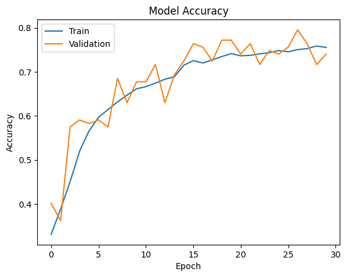

```python
# Plot
plot(history4)
```

```python
# Clear history and fix seed
clear()
```

## **Transfer Learning Architectures**

In this section, we will create several Transfer Learning architectures. For the pre-trained models, we will select three popular architectures namely, VGG16, ResNet v2, and Efficient Net. The difference between these architectures and the previous architectures is that these will require 3 input channels while the earlier ones worked on 'grayscale' images. Therefore, we need to create new DataLoaders.

### **Creating our Data Loaders for Transfer Learning Architectures**

In this section, we are creating data loaders that we will use as inputs to our Neural Network. We will have to go with color_mode = 'rgb' as this is the required format for the transfer learning architectures.

```python
# Augment Function
def augment(image, label):
  # Randomize Brightness
  image = tf.image.random_brightness(image, max_delta=0.1)
  # Flip images horizontaly
  image = tf.image.random_flip_left_right(image)
  # Utilize rotoation in a small variation
  image = rotation(image)
  # Randomize contrast for sharper or duller images
  image = tf.image.random_contrast(image, lower=0.9, upper=1.1)
  # Cap image limit value for functions like random brightness
  image = tf.clip_by_value(image, 0, 255.0)
  # Normalization
  image = preprocess_input(image)
  # Return
  return image, label

# Test Augment Function
def test_augment(image, label):
  # Cap image limit value
  image = tf.clip_by_value(image, 0, 255.0)
  # Normalize
  image = preprocess_input(image)
  # Return
  return image, label
```

```python
# Map this function to every item, use all CPU cores and let tensor flow choose optimal thread count
color_train_df = color_train_df.map(augment, num_parallel_calls=tf.data.AUTOTUNE)
# Prefetch data in the background to avoid idle time on the GPU, let tensor flow choose the optimal number of batches to prefetch based on our system resources.
color_train_df = color_train_df.prefetch(tf.data.AUTOTUNE)

# Normalize test data
color_test_df = color_test_df.map(test_augment, num_parallel_calls=tf.data.AUTOTUNE)
color_test_df = color_test_df.prefetch(tf.data.AUTOTUNE)
```

## **VGG16 Model**

### **Importing the VGG16 Architecture**

```python
# Call VGG16 model, exclude top, so we can write our own classification, use the weights from imagenet, and select our input size
vgg = VGG16(include_top = False, weights = 'imagenet', input_shape = (48, 48, 3))
vgg.summary()
```

```
Downloading data from https://storage.googleapis.com/tensorflow/keras-applications/vgg16/vgg16_weights_tf_dim_ordering_tf_kernels_notop.h5
58889256/58889256 ━━━━━━━━━━━━━━━━━━━━ 0s 0us/step
```

```
Model: "vgg16"
```

```
┏━━━━━━━━━━━━━━━━━━━━━━━━━━━━━━━━━┳━━━━━━━━━━━━━━━━━━━━━━━━┳━━━━━━━━━━━━━━━┓
┃ Layer (type)                    ┃ Output Shape           ┃       Param # ┃
┡━━━━━━━━━━━━━━━━━━━━━━━━━━━━━━━━━╇━━━━━━━━━━━━━━━━━━━━━━━━╇━━━━━━━━━━━━━━━┩
│ input_layer (InputLayer)        │ (None, 48, 48, 3)      │             0 │
├─────────────────────────────────┼────────────────────────┼───────────────┤
│ block1_conv1 (Conv2D)           │ (None, 48, 48, 64)     │         1,792 │
├─────────────────────────────────┼────────────────────────┼───────────────┤
│ block1_conv2 (Conv2D)           │ (None, 48, 48, 64)     │        36,928 │
├─────────────────────────────────┼────────────────────────┼───────────────┤
│ block1_pool (MaxPooling2D)      │ (None, 24, 24, 64)     │             0 │
├─────────────────────────────────┼────────────────────────┼───────────────┤
│ block2_conv1 (Conv2D)           │ (None, 24, 24, 128)    │        73,856 │
├─────────────────────────────────┼────────────────────────┼───────────────┤
│ block2_conv2 (Conv2D)           │ (None, 24, 24, 128)    │       147,584 │
├─────────────────────────────────┼────────────────────────┼───────────────┤
│ block2_pool (MaxPooling2D)      │ (None, 12, 12, 128)    │             0 │
├─────────────────────────────────┼────────────────────────┼───────────────┤
│ block3_conv1 (Conv2D)           │ (None, 12, 12, 256)    │       295,168 │
├─────────────────────────────────┼────────────────────────┼───────────────┤
│ block3_conv2 (Conv2D)           │ (None, 12, 12, 256)    │       590,080 │
├─────────────────────────────────┼────────────────────────┼───────────────┤
│ block3_conv3 (Conv2D)           │ (None, 12, 12, 256)    │       590,080 │
├─────────────────────────────────┼────────────────────────┼───────────────┤
│ block3_pool (MaxPooling2D)      │ (None, 6, 6, 256)      │             0 │
├─────────────────────────────────┼────────────────────────┼───────────────┤
│ block4_conv1 (Conv2D)           │ (None, 6, 6, 512)      │     1,180,160 │
├─────────────────────────────────┼────────────────────────┼───────────────┤
│ block4_conv2 (Conv2D)           │ (None, 6, 6, 512)      │     2,359,808 │
├─────────────────────────────────┼────────────────────────┼───────────────┤
│ block4_conv3 (Conv2D)           │ (None, 6, 6, 512)      │     2,359,808 │
├─────────────────────────────────┼────────────────────────┼───────────────┤
│ block4_pool (MaxPooling2D)      │ (None, 3, 3, 512)      │             0 │
├─────────────────────────────────┼────────────────────────┼───────────────┤
│ block5_conv1 (Conv2D)           │ (None, 3, 3, 512)      │     2,359,808 │
├─────────────────────────────────┼────────────────────────┼───────────────┤
│ block5_conv2 (Conv2D)           │ (None, 3, 3, 512)      │     2,359,808 │
├─────────────────────────────────┼────────────────────────┼───────────────┤
│ block5_conv3 (Conv2D)           │ (None, 3, 3, 512)      │     2,359,808 │
├─────────────────────────────────┼────────────────────────┼───────────────┤
│ block5_pool (MaxPooling2D)      │ (None, 1, 1, 512)      │             0 │
└─────────────────────────────────┴────────────────────────┴───────────────┘
```

```
 Total params: 14,714,688 (56.13 MB)
```

```
 Trainable params: 14,714,688 (56.13 MB)
```

```
 Non-trainable params: 0 (0.00 B)
```

### **Model Building**

- Import VGG16 upto the layer of your choice and add Fully Connected layers on top of it.

```python
# Getting only the conv layers for transfer learning.
transfer_layer = vgg.get_layer('block5_pool')
# Freeze weights to avoid overfitting
vgg.trainable = False
```

```python
# Create model function
def model_v():
  # Initialize
  model = Sequential()
  # Consider transfer learning
  model.add(vgg)
  # Flatten layer, keep feaatures
  model.add(Flatten())
  # Dense layer
  model.add(Dense(256))
  # Normalize
  model.add(BatchNormalization())
  # Activation
  model.add(LeakyReLU(alpha=0.1))
  # Drop
  model.add(Dropout(0.2))
  # 2nd Dense Layer
  model.add(Dense(128))
  # Activation
  model.add(LeakyReLU(alpha=0.1))
  # Drop
  model.add(Dropout(0.2))
  # Dense final, output, 4 categories
  model.add(Dense(4, activation = 'softmax'))
  # Optimizer
  opt = Adam(learning_rate=0.0001)
  # Compile
  model.compile(optimizer = opt, loss = 'categorical_crossentropy', metrics = ['accuracy'])
  # Return
  return model
```

### **Compiling and Training the VGG16 Model**

```python
# Call function and print summary
model_vgg = model_v()
print(model_vgg.summary())
```

```
Model: "sequential"
```

```
┏━━━━━━━━━━━━━━━━━━━━━━━━━━━━━━━━━┳━━━━━━━━━━━━━━━━━━━━━━━━┳━━━━━━━━━━━━━━━┓
┃ Layer (type)                    ┃ Output Shape           ┃       Param # ┃
┡━━━━━━━━━━━━━━━━━━━━━━━━━━━━━━━━━╇━━━━━━━━━━━━━━━━━━━━━━━━╇━━━━━━━━━━━━━━━┩
│ vgg16 (Functional)              │ (None, 1, 1, 512)      │    14,714,688 │
├─────────────────────────────────┼────────────────────────┼───────────────┤
│ flatten (Flatten)               │ (None, 512)            │             0 │
├─────────────────────────────────┼────────────────────────┼───────────────┤
│ dense (Dense)                   │ (None, 256)            │       131,328 │
├─────────────────────────────────┼────────────────────────┼───────────────┤
│ batch_normalization             │ (None, 256)            │         1,024 │
│ (BatchNormalization)            │                        │               │
├─────────────────────────────────┼────────────────────────┼───────────────┤
│ leaky_re_lu (LeakyReLU)         │ (None, 256)            │             0 │
├─────────────────────────────────┼────────────────────────┼───────────────┤
│ dropout (Dropout)               │ (None, 256)            │             0 │
├─────────────────────────────────┼────────────────────────┼───────────────┤
│ dense_1 (Dense)                 │ (None, 128)            │        32,896 │
├─────────────────────────────────┼────────────────────────┼───────────────┤
│ leaky_re_lu_1 (LeakyReLU)       │ (None, 128)            │             0 │
├─────────────────────────────────┼────────────────────────┼───────────────┤
│ dropout_1 (Dropout)             │ (None, 128)            │             0 │
├─────────────────────────────────┼────────────────────────┼───────────────┤
│ dense_2 (Dense)                 │ (None, 4)              │           516 │
└─────────────────────────────────┴────────────────────────┴───────────────┘
```

```
 Total params: 14,880,452 (56.76 MB)
```

```
 Trainable params: 165,252 (645.52 KB)
```

```
 Non-trainable params: 14,715,200 (56.13 MB)
```

```
None
```

```python
# Introduce callbacks to improve training
# Save checkpoint in best values
checkpoint = ModelCheckpoint("./modelv.h5", monitor='val_acc', verbose=1, save_best_only=True, mode='max')


# Stop when the improvement is low
early_stopping = EarlyStopping(monitor = 'val_loss',
                          min_delta = 0,     # Changing factors to see behaviour in model
                          patience = 8,
                          verbose = 1,
                          restore_best_weights = True
                          )
# Reduce learning rate when validation loss flattens
reduce_learningrate = ReduceLROnPlateau(monitor = 'val_loss',
                              factor = 0.3,     # Changing factors to see behaviour in model
                              patience = 3,
                              verbose = 1,
                              min_delta = 0.0001) # Changing factors to see behaviour in model

callbacks_list = [early_stopping, checkpoint, reduce_learningrate]
```

```python
# Fitting the VGG model
history_vgg = model_vgg.fit(color_train_df, validation_data = color_test_df, batch_size = 32, verbose = 1, epochs = 30, callbacks = callbacks_list)
```

```
472/472 ━━━━━━━━━━━━━━━━━━━━ 22s 35ms/step - accuracy: 0.2787 - loss: 1.4843 - val_accuracy: 0.2835 - val_loss: 1.4594 - learning_rate: 1.0000e-04
472/472 ━━━━━━━━━━━━━━━━━━━━ 10s 21ms/step - accuracy: 0.2870 - loss: 1.4148 - val_accuracy: 0.3307 - val_loss: 1.4038 - learning_rate: 1.0000e-04
472/472 ━━━━━━━━━━━━━━━━━━━━ 21s 23ms/step - accuracy: 0.3056 - loss: 1.3884 - val_accuracy: 0.3228 - val_loss: 1.4096 - learning_rate: 1.0000e-04
472/472 ━━━━━━━━━━━━━━━━━━━━ 11s 23ms/step - accuracy: 0.3160 - loss: 1.3694 - val_accuracy: 0.3307 - val_loss: 1.4076 - learning_rate: 1.0000e-04
472/472 ━━━━━━━━━━━━━━━━━━━━ 11s 24ms/step - accuracy: 0.3080 - loss: 1.3706 - val_accuracy: 0.2598 - val_loss: 1.3777 - learning_rate: 1.0000e-04
472/472 ━━━━━━━━━━━━━━━━━━━━ 20s 22ms/step - accuracy: 0.3123 - loss: 1.3632 - val_accuracy: 0.3465 - val_loss: 1.4068 - learning_rate: 1.0000e-04
472/472 ━━━━━━━━━━━━━━━━━━━━ 11s 23ms/step - accuracy: 0.3262 - loss: 1.3589 - val_accuracy: 0.2913 - val_loss: 1.4193 - learning_rate: 1.0000e-04
472/472 ━━━━━━━━━━━━━━━━━━━━ 11s 23ms/step - accuracy: 0.3191 - loss: 1.3577 - val_accuracy: 0.3543 - val_loss: 1.3487 - learning_rate: 1.0000e-04
472/472 ━━━━━━━━━━━━━━━━━━━━ 10s 20ms/step - accuracy: 0.3300 - loss: 1.3524 - val_accuracy: 0.2992 - val_loss: 1.3701 - learning_rate: 1.0000e-04
472/472 ━━━━━━━━━━━━━━━━━━━━ 10s 21ms/step - accuracy: 0.3291 - loss: 1.3523 - val_accuracy: 0.3150 - val_loss: 1.4215 - learning_rate: 1.0000e-04
469/472 ━━━━━━━━━━━━━━━━━━━━ 0s 22ms/step - accuracy: 0.3310 - loss: 1.3487
Epoch 11: ReduceLROnPlateau reducing learning rate to 2.9999999242136255e-05.
472/472 ━━━━━━━━━━━━━━━━━━━━ 11s 23ms/step - accuracy: 0.3309 - loss: 1.3487 - val_accuracy: 0.2992 - val_loss: 1.4416 - learning_rate: 1.0000e-04
472/472 ━━━━━━━━━━━━━━━━━━━━ 11s 22ms/step - accuracy: 0.3346 - loss: 1.3462 - val_accuracy: 0.3071 - val_loss: 1.3622 - learning_rate: 3.0000e-05
472/472 ━━━━━━━━━━━━━━━━━━━━ 11s 22ms/step - accuracy: 0.3339 - loss: 1.3485 - val_accuracy: 0.3780 - val_loss: 1.3660 - learning_rate: 3.0000e-05
472/472 ━━━━━━━━━━━━━━━━━━━━ 10s 20ms/step - accuracy: 0.3371 - loss: 1.3476 - val_accuracy: 0.3307 - val_loss: 1.3440 - learning_rate: 3.0000e-05
472/472 ━━━━━━━━━━━━━━━━━━━━ 11s 23ms/step - accuracy: 0.3341 - loss: 1.3483 - val_accuracy: 0.3150 - val_loss: 1.3591 - learning_rate: 3.0000e-05
472/472 ━━━━━━━━━━━━━━━━━━━━ 11s 23ms/step - accuracy: 0.3321 - loss: 1.3472 - val_accuracy: 0.3071 - val_loss: 1.3431 - learning_rate: 3.0000e-05
472/472 ━━━━━━━━━━━━━━━━━━━━ 11s 22ms/step - accuracy: 0.3393 - loss: 1.3417 - val_accuracy: 0.3307 - val_loss: 1.3399 - learning_rate: 3.0000e-05
472/472 ━━━━━━━━━━━━━━━━━━━━ 9s 19ms/step - accuracy: 0.3434 - loss: 1.3390 - val_accuracy: 0.2913 - val_loss: 1.3475 - learning_rate: 3.0000e-05
472/472 ━━━━━━━━━━━━━━━━━━━━ 11s 22ms/step - accuracy: 0.3345 - loss: 1.3440 - val_accuracy: 0.3228 - val_loss: 1.3473 - learning_rate: 3.0000e-05
472/472 ━━━━━━━━━━━━━━━━━━━━ 0s 22ms/step - accuracy: 0.3389 - loss: 1.3443
Epoch 20: ReduceLROnPlateau reducing learning rate to 8.999999772640877e-06.
472/472 ━━━━━━━━━━━━━━━━━━━━ 11s 23ms/step - accuracy: 0.3389 - loss: 1.3443 - val_accuracy: 0.3465 - val_loss: 1.3634 - learning_rate: 3.0000e-05
472/472 ━━━━━━━━━━━━━━━━━━━━ 11s 23ms/step - accuracy: 0.3505 - loss: 1.3420 - val_accuracy: 0.3071 - val_loss: 1.3380 - learning_rate: 9.0000e-06
472/472 ━━━━━━━━━━━━━━━━━━━━ 10s 20ms/step - accuracy: 0.3356 - loss: 1.3445 - val_accuracy: 0.3071 - val_loss: 1.3428 - learning_rate: 9.0000e-06
472/472 ━━━━━━━━━━━━━━━━━━━━ 10s 20ms/step - accuracy: 0.3349 - loss: 1.3475 - val_accuracy: 0.2835 - val_loss: 1.3415 - learning_rate: 9.0000e-06
472/472 ━━━━━━━━━━━━━━━━━━━━ 0s 22ms/step - accuracy: 0.3370 - loss: 1.3449
Epoch 24: ReduceLROnPlateau reducing learning rate to 2.6999998226528985e-06.
472/472 ━━━━━━━━━━━━━━━━━━━━ 11s 23ms/step - accuracy: 0.3370 - loss: 1.3449 - val_accuracy: 0.3071 - val_loss: 1.3426 - learning_rate: 9.0000e-06
472/472 ━━━━━━━━━━━━━━━━━━━━ 12s 26ms/step - accuracy: 0.3434 - loss: 1.3444 - val_accuracy: 0.3228 - val_loss: 1.3409 - learning_rate: 2.7000e-06
472/472 ━━━━━━━━━━━━━━━━━━━━ 18s 21ms/step - accuracy: 0.3402 - loss: 1.3422 - val_accuracy: 0.3228 - val_loss: 1.3408 - learning_rate: 2.7000e-06
469/472 ━━━━━━━━━━━━━━━━━━━━ 0s 22ms/step - accuracy: 0.3407 - loss: 1.3419
Epoch 27: ReduceLROnPlateau reducing learning rate to 8.099999604382901e-07.
472/472 ━━━━━━━━━━━━━━━━━━━━ 11s 22ms/step - accuracy: 0.3406 - loss: 1.3419 - val_accuracy: 0.3150 - val_loss: 1.3394 - learning_rate: 2.7000e-06
472/472 ━━━━━━━━━━━━━━━━━━━━ 21s 23ms/step - accuracy: 0.3348 - loss: 1.3420 - val_accuracy: 0.3071 - val_loss: 1.3399 - learning_rate: 8.1000e-07
472/472 ━━━━━━━━━━━━━━━━━━━━ 9s 19ms/step - accuracy: 0.3289 - loss: 1.3478 - val_accuracy: 0.3071 - val_loss: 1.3400 - learning_rate: 8.1000e-07
Epoch 29: early stopping
Restoring model weights from the end of the best epoch: 21.
```

### **Evaluating the VGG16 model**

```python
# Evaluating on the Test set
model_vgg.evaluate(color_test_df)
```

```
4/4 ━━━━━━━━━━━━━━━━━━━━ 0s 32ms/step - accuracy: 0.2697 - loss: 1.3709
```

```
[1.3380237817764282, 0.30708661675453186]
```

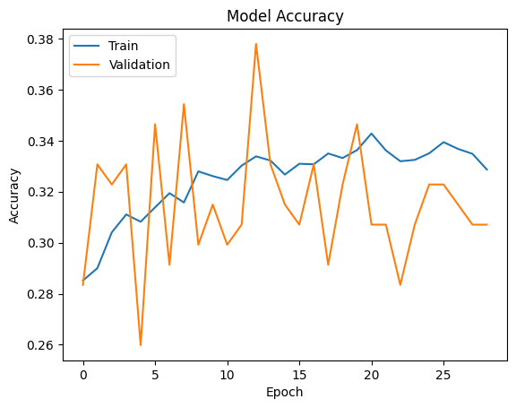

```python
# Plotting the loss vs epoch curve for the basic CNN model without Transfer Learning
plot(history_vgg)
```

```python
# Clear
clear()
```

**Think About It:**

**Observations and Insights:** We can notice spikes on the validation set, we might need to adjust the batch on the validation set. That will lead to a smoother gradient.

**Note: You can even go back and build your own architecture on top of the VGG16 Transfer layer and see if you can improve the performance**

```python
Resnet = ap.ResNet101(include_top = False, weights = "imagenet", input_shape=(48,48,3))
Resnet.summary()
```

```
Downloading data from https://storage.googleapis.com/tensorflow/keras-applications/resnet/resnet101_weights_tf_dim_ordering_tf_kernels_notop.h5
171446536/171446536 ━━━━━━━━━━━━━━━━━━━━ 1s 0us/step
```

```
Model: "resnet101"
```

[output not shown]

[output cut: 983 more lines]

```
│ conv5_block3_2_relu │ (None, 2, 2, 512) │          0 │ conv5_block3_2_b… │
│ (Activation)        │                   │            │                   │
├─────────────────────┼───────────────────┼────────────┼───────────────────┤
│ conv5_block3_3_conv │ (None, 2, 2,      │  1,050,624 │ conv5_block3_2_r… │
│ (Conv2D)            │ 2048)             │            │                   │
├─────────────────────┼───────────────────┼────────────┼───────────────────┤
│ conv5_block3_3_bn   │ (None, 2, 2,      │      8,192 │ conv5_block3_3_c… │
│ (BatchNormalizatio… │ 2048)             │            │                   │
├─────────────────────┼───────────────────┼────────────┼───────────────────┤
│ conv5_block3_add    │ (None, 2, 2,      │          0 │ conv5_block2_out… │
│ (Add)               │ 2048)             │            │ conv5_block3_3_b… │
├─────────────────────┼───────────────────┼────────────┼───────────────────┤
│ conv5_block3_out    │ (None, 2, 2,      │          0 │ conv5_block3_add… │
│ (Activation)        │ 2048)             │            │                   │
└─────────────────────┴───────────────────┴────────────┴───────────────────┘
```

```
 Total params: 42,658,176 (162.73 MB)
```

```
 Trainable params: 42,552,832 (162.33 MB)
```

```
 Non-trainable params: 105,344 (411.50 KB)
```

### **Model Building**

```python
transfer_layer = Resnet.get_layer('conv5_block3_add')
Resnet.trainable = False
```

```python
# Create model function
def model_r():
  # Initialize
  model = Sequential()
  # Consider transfer learning
  model.add(Resnet)
  # Flatten layer, keep feaatures
  model.add(Flatten())
  # Dense layer
  model.add(Dense(128))
  # Normalize
  model.add(BatchNormalization())
  # Activation
  model.add(LeakyReLU(alpha=0.1))
  # Drop
  model.add(Dropout(0.2))
  # 2nd Dense Layer
  model.add(Dense(64))
  # Activation
  model.add(LeakyReLU(alpha=0.1))
  # Drop
  model.add(Dropout(0.2))
  # Dense final, output, 4 categories
  model.add(Dense(4, activation = 'softmax'))
  # Optimizer
  opt = Adam(learning_rate=0.0001)
  # Compile
  model.compile(optimizer = opt, loss = 'categorical_crossentropy', metrics = ['accuracy'])
  # Return
  return model
```

### **Compiling and Training the Model**

```python
model_resnet = model_r()
print(model_resnet.summary())
```

```
Model: "sequential"
```

```
┏━━━━━━━━━━━━━━━━━━━━━━━━━━━━━━━━━┳━━━━━━━━━━━━━━━━━━━━━━━━┳━━━━━━━━━━━━━━━┓
┃ Layer (type)                    ┃ Output Shape           ┃       Param # ┃
┡━━━━━━━━━━━━━━━━━━━━━━━━━━━━━━━━━╇━━━━━━━━━━━━━━━━━━━━━━━━╇━━━━━━━━━━━━━━━┩
│ resnet101 (Functional)          │ (None, 2, 2, 2048)     │    42,658,176 │
├─────────────────────────────────┼────────────────────────┼───────────────┤
│ flatten (Flatten)               │ (None, 8192)           │             0 │
├─────────────────────────────────┼────────────────────────┼───────────────┤
│ dense (Dense)                   │ (None, 128)            │     1,048,704 │
├─────────────────────────────────┼────────────────────────┼───────────────┤
│ batch_normalization             │ (None, 128)            │           512 │
│ (BatchNormalization)            │                        │               │
├─────────────────────────────────┼────────────────────────┼───────────────┤
│ leaky_re_lu (LeakyReLU)         │ (None, 128)            │             0 │
├─────────────────────────────────┼────────────────────────┼───────────────┤
│ dropout (Dropout)               │ (None, 128)            │             0 │
├─────────────────────────────────┼────────────────────────┼───────────────┤
│ dense_1 (Dense)                 │ (None, 64)             │         8,256 │
├─────────────────────────────────┼────────────────────────┼───────────────┤
│ leaky_re_lu_1 (LeakyReLU)       │ (None, 64)             │             0 │
├─────────────────────────────────┼────────────────────────┼───────────────┤
│ dropout_1 (Dropout)             │ (None, 64)             │             0 │
├─────────────────────────────────┼────────────────────────┼───────────────┤
│ dense_2 (Dense)                 │ (None, 4)              │           260 │
└─────────────────────────────────┴────────────────────────┴───────────────┘
```

```
 Total params: 43,715,908 (166.76 MB)
```

```
 Trainable params: 1,057,476 (4.03 MB)
```

```
 Non-trainable params: 42,658,432 (162.73 MB)
```

```
None
```

```python
# Introduce callbacks to improve training
# Save checkpoint in best values
checkpoint = ModelCheckpoint("./modelr.h5", monitor='val_acc', verbose=1, save_best_only=True, mode='max')


# Stop when the improvement is low
early_stopping = EarlyStopping(monitor = 'val_loss',
                          min_delta = 0,     # Changing factors to see behaviour in model
                          patience = 10,
                          verbose = 1,
                          restore_best_weights = True
                          )
# Reduce learning rate when validation loss flattens
reduce_learningrate = ReduceLROnPlateau(monitor = 'val_loss',
                              factor = 0.5,     # Changing factors to see behaviour in model
                              patience = 3,
                              verbose = 1,
                              min_delta = 0.0003) # Changing factors to see behaviour in model

callbacks_list = [early_stopping, checkpoint, reduce_learningrate]
```

```python
# Fit model
history_resnet = model_resnet.fit(color_train_df, validation_data = color_test_df, batch_size = 32, verbose = 1, epochs = 30, callbacks = callbacks_list)
```

```
472/472 ━━━━━━━━━━━━━━━━━━━━ 55s 71ms/step - accuracy: 0.2844 - loss: 1.4852 - val_accuracy: 0.3386 - val_loss: 1.3484 - learning_rate: 1.0000e-04
472/472 ━━━━━━━━━━━━━━━━━━━━ 14s 29ms/step - accuracy: 0.3199 - loss: 1.3846 - val_accuracy: 0.3228 - val_loss: 1.3952 - learning_rate: 1.0000e-04
472/472 ━━━━━━━━━━━━━━━━━━━━ 21s 31ms/step - accuracy: 0.3366 - loss: 1.3558 - val_accuracy: 0.3228 - val_loss: 1.4551 - learning_rate: 1.0000e-04
472/472 ━━━━━━━━━━━━━━━━━━━━ 20s 29ms/step - accuracy: 0.3492 - loss: 1.3405 - val_accuracy: 0.3071 - val_loss: 1.3274 - learning_rate: 1.0000e-04
472/472 ━━━━━━━━━━━━━━━━━━━━ 20s 29ms/step - accuracy: 0.3489 - loss: 1.3372 - val_accuracy: 0.3307 - val_loss: 1.3416 - learning_rate: 1.0000e-04
472/472 ━━━━━━━━━━━━━━━━━━━━ 14s 29ms/step - accuracy: 0.3629 - loss: 1.3218 - val_accuracy: 0.3386 - val_loss: 1.3380 - learning_rate: 1.0000e-04
472/472 ━━━━━━━━━━━━━━━━━━━━ 14s 29ms/step - accuracy: 0.3637 - loss: 1.3130 - val_accuracy: 0.3701 - val_loss: 1.3195 - learning_rate: 1.0000e-04
472/472 ━━━━━━━━━━━━━━━━━━━━ 14s 29ms/step - accuracy: 0.3612 - loss: 1.3135 - val_accuracy: 0.3228 - val_loss: 1.4086 - learning_rate: 1.0000e-04
472/472 ━━━━━━━━━━━━━━━━━━━━ 14s 29ms/step - accuracy: 0.3823 - loss: 1.2987 - val_accuracy: 0.3701 - val_loss: 1.3593 - learning_rate: 1.0000e-04
470/472 ━━━━━━━━━━━━━━━━━━━━ 0s 30ms/step - accuracy: 0.3933 - loss: 1.2974
Epoch 10: ReduceLROnPlateau reducing learning rate to 4.999999873689376e-05.
472/472 ━━━━━━━━━━━━━━━━━━━━ 21s 31ms/step - accuracy: 0.3933 - loss: 1.2974 - val_accuracy: 0.3386 - val_loss: 1.3387 - learning_rate: 1.0000e-04
472/472 ━━━━━━━━━━━━━━━━━━━━ 15s 30ms/step - accuracy: 0.3828 - loss: 1.2994 - val_accuracy: 0.4173 - val_loss: 1.2723 - learning_rate: 5.0000e-05
472/472 ━━━━━━━━━━━━━━━━━━━━ 15s 31ms/step - accuracy: 0.4005 - loss: 1.2755 - val_accuracy: 0.3937 - val_loss: 1.2545 - learning_rate: 5.0000e-05
472/472 ━━━━━━━━━━━━━━━━━━━━ 14s 30ms/step - accuracy: 0.4006 - loss: 1.2765 - val_accuracy: 0.4094 - val_loss: 1.2474 - learning_rate: 5.0000e-05
472/472 ━━━━━━━━━━━━━━━━━━━━ 14s 30ms/step - accuracy: 0.3995 - loss: 1.2751 - val_accuracy: 0.4016 - val_loss: 1.2474 - learning_rate: 5.0000e-05
472/472 ━━━━━━━━━━━━━━━━━━━━ 15s 31ms/step - accuracy: 0.4132 - loss: 1.2671 - val_accuracy: 0.4252 - val_loss: 1.2372 - learning_rate: 5.0000e-05
472/472 ━━━━━━━━━━━━━━━━━━━━ 15s 31ms/step - accuracy: 0.4099 - loss: 1.2709 - val_accuracy: 0.4882 - val_loss: 1.2203 - learning_rate: 5.0000e-05
472/472 ━━━━━━━━━━━━━━━━━━━━ 21s 32ms/step - accuracy: 0.4074 - loss: 1.2644 - val_accuracy: 0.4016 - val_loss: 1.2479 - learning_rate: 5.0000e-05
472/472 ━━━━━━━━━━━━━━━━━━━━ 19s 28ms/step - accuracy: 0.4185 - loss: 1.2584 - val_accuracy: 0.3622 - val_loss: 1.2698 - learning_rate: 5.0000e-05
472/472 ━━━━━━━━━━━━━━━━━━━━ 14s 29ms/step - accuracy: 0.4208 - loss: 1.2569 - val_accuracy: 0.4961 - val_loss: 1.2074 - learning_rate: 5.0000e-05
472/472 ━━━━━━━━━━━━━━━━━━━━ 13s 28ms/step - accuracy: 0.4193 - loss: 1.2496 - val_accuracy: 0.4016 - val_loss: 1.2368 - learning_rate: 5.0000e-05
472/472 ━━━━━━━━━━━━━━━━━━━━ 14s 29ms/step - accuracy: 0.4271 - loss: 1.2509 - val_accuracy: 0.4803 - val_loss: 1.1830 - learning_rate: 5.0000e-05
472/472 ━━━━━━━━━━━━━━━━━━━━ 14s 28ms/step - accuracy: 0.4279 - loss: 1.2474 - val_accuracy: 0.3701 - val_loss: 1.2916 - learning_rate: 5.0000e-05
472/472 ━━━━━━━━━━━━━━━━━━━━ 21s 29ms/step - accuracy: 0.4217 - loss: 1.2480 - val_accuracy: 0.3780 - val_loss: 1.2182 - learning_rate: 5.0000e-05
471/472 ━━━━━━━━━━━━━━━━━━━━ 0s 28ms/step - accuracy: 0.4316 - loss: 1.2399
Epoch 24: ReduceLROnPlateau reducing learning rate to 2.499999936844688e-05.
472/472 ━━━━━━━━━━━━━━━━━━━━ 14s 28ms/step - accuracy: 0.4316 - loss: 1.2399 - val_accuracy: 0.3150 - val_loss: 1.4176 - learning_rate: 5.0000e-05
472/472 ━━━━━━━━━━━━━━━━━━━━ 14s 29ms/step - accuracy: 0.4209 - loss: 1.2438 - val_accuracy: 0.5197 - val_loss: 1.1719 - learning_rate: 2.5000e-05
472/472 ━━━━━━━━━━━━━━━━━━━━ 20s 28ms/step - accuracy: 0.4272 - loss: 1.2493 - val_accuracy: 0.4488 - val_loss: 1.1800 - learning_rate: 2.5000e-05
472/472 ━━━━━━━━━━━━━━━━━━━━ 14s 28ms/step - accuracy: 0.4410 - loss: 1.2298 - val_accuracy: 0.4961 - val_loss: 1.1665 - learning_rate: 2.5000e-05
472/472 ━━━━━━━━━━━━━━━━━━━━ 21s 29ms/step - accuracy: 0.4401 - loss: 1.2336 - val_accuracy: 0.4488 - val_loss: 1.2109 - learning_rate: 2.5000e-05
472/472 ━━━━━━━━━━━━━━━━━━━━ 14s 29ms/step - accuracy: 0.4354 - loss: 1.2336 - val_accuracy: 0.3858 - val_loss: 1.2602 - learning_rate: 2.5000e-05
472/472 ━━━━━━━━━━━━━━━━━━━━ 16s 33ms/step - accuracy: 0.4402 - loss: 1.2328 - val_accuracy: 0.4567 - val_loss: 1.1613 - learning_rate: 2.5000e-05
Restoring model weights from the end of the best epoch: 30.
```

### **Evaluating the ResNet Model**

```python
model_resnet.evaluate(color_test_df)
```

```
4/4 ━━━━━━━━━━━━━━━━━━━━ 0s 45ms/step - accuracy: 0.4546 - loss: 1.1526
```

```
[1.1613202095031738, 0.4566929042339325]
```

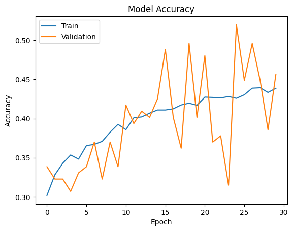

```python
#Plot
plot(history_resnet)
```

```python
# Clear
clear()
```

**Observations and Insights:__** We experienced the same issue as the VGG16 model, the accuracy is low. We need to dive look into a better architecture.

**Note: You can even go back and build your own architecture on top of the ResNet Transfer layer and see if you can improve the performance.**

## **EfficientNet Model**

```python
EfficientNet = ap.EfficientNetV2B2(include_top=False, weights="imagenet", input_shape= (48, 48, 3))

EfficientNet.summary()
```

```
Downloading data from https://storage.googleapis.com/tensorflow/keras-applications/efficientnet_v2/efficientnetv2-b2_notop.h5
35839040/35839040 ━━━━━━━━━━━━━━━━━━━━ 0s 0us/step
```

```
Model: "efficientnetv2-b2"
```

```
┏━━━━━━━━━━━━━━━━━━━━━┳━━━━━━━━━━━━━━━━━━━┳━━━━━━━━━━━━┳━━━━━━━━━━━━━━━━━━━┓
┃ Layer (type)        ┃ Output Shape      ┃    Param # ┃ Connected to      ┃
┡━━━━━━━━━━━━━━━━━━━━━╇━━━━━━━━━━━━━━━━━━━╇━━━━━━━━━━━━╇━━━━━━━━━━━━━━━━━━━┩
│ input_layer         │ (None, 48, 48, 3) │          0 │ -                 │
│ (InputLayer)        │                   │            │                   │
├─────────────────────┼───────────────────┼────────────┼───────────────────┤
│ rescaling           │ (None, 48, 48, 3) │          0 │ input_layer[0][0] │
│ (Rescaling)         │                   │            │                   │
├─────────────────────┼───────────────────┼────────────┼───────────────────┤
│ normalization       │ (None, 48, 48, 3) │          0 │ rescaling[0][0]   │
│ (Normalization)     │                   │            │                   │
├─────────────────────┼───────────────────┼────────────┼───────────────────┤
│ stem_conv (Conv2D)  │ (None, 24, 24,    │        864 │ normalization[0]… │
│                     │ 32)               │            │                   │
├─────────────────────┼───────────────────┼────────────┼───────────────────┤
│ stem_bn             │ (None, 24, 24,    │        128 │ stem_conv[0][0]   │
│ (BatchNormalizatio… │ 32)               │            │                   │
├─────────────────────┼───────────────────┼────────────┼───────────────────┤
│ stem_activation     │ (None, 24, 24,    │          0 │ stem_bn[0][0]     │
│ (Activation)        │ 32)               │            │                   │
├─────────────────────┼───────────────────┼────────────┼───────────────────┤
│ block1a_project_co… │ (None, 24, 24,    │      4,608 │ stem_activation[… │
│ (Conv2D)            │ 16)               │            │                   │
├─────────────────────┼───────────────────┼────────────┼───────────────────┤
│ block1a_project_bn  │ (None, 24, 24,    │         64 │ block1a_project_… │
│ (BatchNormalizatio… │ 16)               │            │                   │
├─────────────────────┼───────────────────┼────────────┼───────────────────┤
│ block1a_project_ac… │ (None, 24, 24,    │          0 │ block1a_project_… │
│ (Activation)        │ 16)               │            │                   │
├─────────────────────┼───────────────────┼────────────┼───────────────────┤
│ block1b_project_co… │ (None, 24, 24,    │      2,304 │ block1a_project_… │
│ (Conv2D)            │ 16)               │            │                   │
├─────────────────────┼───────────────────┼────────────┼───────────────────┤
│ block1b_project_bn  │ (None, 24, 24,    │         64 │ block1b_project_… │
│ (BatchNormalizatio… │ 16)               │            │                   │
├─────────────────────┼───────────────────┼────────────┼───────────────────┤
│ block1b_project_ac… │ (None, 24, 24,    │          0 │ block1b_project_… │
│ (Activation)        │ 16)               │            │                   │
├─────────────────────┼───────────────────┼────────────┼───────────────────┤
│ block1b_drop        │ (None, 24, 24,    │          0 │ block1b_project_… │
```

[output cut: 995 more lines]

```
│ block6j_drop        │ (None, 2, 2, 208) │          0 │ block6j_project_… │
│ (Dropout)           │                   │            │                   │
├─────────────────────┼───────────────────┼────────────┼───────────────────┤
│ block6j_add (Add)   │ (None, 2, 2, 208) │          0 │ block6j_drop[0][… │
│                     │                   │            │ block6i_add[0][0] │
├─────────────────────┼───────────────────┼────────────┼───────────────────┤
│ top_conv (Conv2D)   │ (None, 2, 2,      │    292,864 │ block6j_add[0][0] │
│                     │ 1408)             │            │                   │
├─────────────────────┼───────────────────┼────────────┼───────────────────┤
│ top_bn              │ (None, 2, 2,      │      5,632 │ top_conv[0][0]    │
│ (BatchNormalizatio… │ 1408)             │            │                   │
├─────────────────────┼───────────────────┼────────────┼───────────────────┤
│ top_activation      │ (None, 2, 2,      │          0 │ top_bn[0][0]      │
│ (Activation)        │ 1408)             │            │                   │
└─────────────────────┴───────────────────┴────────────┴───────────────────┘
```

```
 Total params: 8,769,374 (33.45 MB)
```

```
 Trainable params: 8,687,086 (33.14 MB)
```

```
 Non-trainable params: 82,288 (321.44 KB)
```

### **Model Building**

- Import EfficientNet upto the layer of your choice and add Fully Connected layers on top of it.

```python
transfer_layer = EfficientNet.get_layer('block6a_expand_activation') ##CHECK LAYER
EfficientNet.trainable = False
```

```python
# Create function

def model_e():
    # Initialize
  model = Sequential()
  # Consider transfer learning
  model.add(EfficientNet)
  # Flatten layer, keep feaatures
  model.add(Flatten())
  # Dense layer
  model.add(Dense(128))
  # Activation
  model.add(LeakyReLU(alpha=0.1))
  # Drop
  model.add(Dropout(0.2))
  # 2nd Dense Layer
  model.add(Dense(64))
  # Normalize
  model.add(BatchNormalization())
  # Activation
  model.add(LeakyReLU(alpha=0.1))
  # Drop
  model.add(Dropout(0.2))
  # Dense final, output, 4 categories
  model.add(Dense(4, activation = 'softmax'))
  # Optimizer
  opt = Adam(learning_rate=0.0001)
  # Compile
  model.compile(optimizer = opt, loss = 'categorical_crossentropy', metrics = ['accuracy'])
  # Return
  return model
```

### **Compiling and Training the Model**

```python
model_en = model_e()
print(model_en.summary())
```

```
Model: "sequential"
```

```
┏━━━━━━━━━━━━━━━━━━━━━━━━━━━━━━━━━┳━━━━━━━━━━━━━━━━━━━━━━━━┳━━━━━━━━━━━━━━━┓
┃ Layer (type)                    ┃ Output Shape           ┃       Param # ┃
┡━━━━━━━━━━━━━━━━━━━━━━━━━━━━━━━━━╇━━━━━━━━━━━━━━━━━━━━━━━━╇━━━━━━━━━━━━━━━┩
│ efficientnetv2-b2 (Functional)  │ (None, 2, 2, 1408)     │     8,769,374 │
├─────────────────────────────────┼────────────────────────┼───────────────┤
│ flatten (Flatten)               │ (None, 5632)           │             0 │
├─────────────────────────────────┼────────────────────────┼───────────────┤
│ dense (Dense)                   │ (None, 128)            │       721,024 │
├─────────────────────────────────┼────────────────────────┼───────────────┤
│ leaky_re_lu (LeakyReLU)         │ (None, 128)            │             0 │
├─────────────────────────────────┼────────────────────────┼───────────────┤
│ dropout (Dropout)               │ (None, 128)            │             0 │
├─────────────────────────────────┼────────────────────────┼───────────────┤
│ dense_1 (Dense)                 │ (None, 64)             │         8,256 │
├─────────────────────────────────┼────────────────────────┼───────────────┤
│ batch_normalization             │ (None, 64)             │           256 │
│ (BatchNormalization)            │                        │               │
├─────────────────────────────────┼────────────────────────┼───────────────┤
│ leaky_re_lu_1 (LeakyReLU)       │ (None, 64)             │             0 │
├─────────────────────────────────┼────────────────────────┼───────────────┤
│ dropout_1 (Dropout)             │ (None, 64)             │             0 │
├─────────────────────────────────┼────────────────────────┼───────────────┤
│ dense_2 (Dense)                 │ (None, 4)              │           260 │
└─────────────────────────────────┴────────────────────────┴───────────────┘
```

```
 Total params: 9,499,170 (36.24 MB)
```

```
 Trainable params: 729,668 (2.78 MB)
```

```
 Non-trainable params: 8,769,502 (33.45 MB)
```

```
None
```

```python
# Introduce callbacks to improve training
# Save checkpoint in best values
checkpoint = ModelCheckpoint("./modelr.h5", monitor='val_acc', verbose=1, save_best_only=True, mode='max')


# Stop when the improvement is low
early_stopping = EarlyStopping(monitor = 'val_loss',
                          min_delta = 0,     # Changing factors to see behaviour in model
                          patience = 10,
                          verbose = 1,
                          restore_best_weights = True
                          )
# Reduce learning rate when validation loss flattens
reduce_learningrate = ReduceLROnPlateau(monitor = 'val_loss',
                              factor = 0.25,     # Changing factors to see behaviour in model
                              patience = 2,
                              verbose = 1,
                              min_delta = 0.0001) # Changing factors to see behaviour in model

callbacks_list = [early_stopping, checkpoint, reduce_learningrate]
```

```python
# Fit
history_en = model_en.fit(color_train_df, validation_data = color_test_df, batch_size = 64, verbose = 1, epochs = 20, callbacks = callbacks_list)
```

```
472/472 ━━━━━━━━━━━━━━━━━━━━ 73s 96ms/step - accuracy: 0.2489 - loss: 1.6099 - val_accuracy: 0.2441 - val_loss: 1.4004 - learning_rate: 1.0000e-04
472/472 ━━━━━━━━━━━━━━━━━━━━ 13s 27ms/step - accuracy: 0.2567 - loss: 1.4985 - val_accuracy: 0.2520 - val_loss: 1.4152 - learning_rate: 1.0000e-04
471/472 ━━━━━━━━━━━━━━━━━━━━ 0s 25ms/step - accuracy: 0.2496 - loss: 1.4856
Epoch 3: ReduceLROnPlateau reducing learning rate to 2.499999936844688e-05.
472/472 ━━━━━━━━━━━━━━━━━━━━ 12s 26ms/step - accuracy: 0.2496 - loss: 1.4855 - val_accuracy: 0.2441 - val_loss: 1.4049 - learning_rate: 1.0000e-04
472/472 ━━━━━━━━━━━━━━━━━━━━ 21s 27ms/step - accuracy: 0.2591 - loss: 1.4584 - val_accuracy: 0.2441 - val_loss: 1.3964 - learning_rate: 2.5000e-05
472/472 ━━━━━━━━━━━━━━━━━━━━ 13s 27ms/step - accuracy: 0.2582 - loss: 1.4573 - val_accuracy: 0.2441 - val_loss: 1.3992 - learning_rate: 2.5000e-05
472/472 ━━━━━━━━━━━━━━━━━━━━ 13s 27ms/step - accuracy: 0.2536 - loss: 1.4522 - val_accuracy: 0.2441 - val_loss: 1.3925 - learning_rate: 2.5000e-05
472/472 ━━━━━━━━━━━━━━━━━━━━ 13s 27ms/step - accuracy: 0.2548 - loss: 1.4502 - val_accuracy: 0.2441 - val_loss: 1.3903 - learning_rate: 2.5000e-05
472/472 ━━━━━━━━━━━━━━━━━━━━ 22s 31ms/step - accuracy: 0.2606 - loss: 1.4483 - val_accuracy: 0.2441 - val_loss: 1.3980 - learning_rate: 2.5000e-05
469/472 ━━━━━━━━━━━━━━━━━━━━ 0s 27ms/step - accuracy: 0.2569 - loss: 1.4460
Epoch 9: ReduceLROnPlateau reducing learning rate to 6.24999984211172e-06.
472/472 ━━━━━━━━━━━━━━━━━━━━ 19s 27ms/step - accuracy: 0.2569 - loss: 1.4460 - val_accuracy: 0.2441 - val_loss: 1.3989 - learning_rate: 2.5000e-05
472/472 ━━━━━━━━━━━━━━━━━━━━ 13s 27ms/step - accuracy: 0.2568 - loss: 1.4464 - val_accuracy: 0.2441 - val_loss: 1.3978 - learning_rate: 6.2500e-06
469/472 ━━━━━━━━━━━━━━━━━━━━ 0s 27ms/step - accuracy: 0.2553 - loss: 1.4378
Epoch 11: ReduceLROnPlateau reducing learning rate to 1.56249996052793e-06.
472/472 ━━━━━━━━━━━━━━━━━━━━ 13s 27ms/step - accuracy: 0.2553 - loss: 1.4378 - val_accuracy: 0.2441 - val_loss: 1.3980 - learning_rate: 6.2500e-06
472/472 ━━━━━━━━━━━━━━━━━━━━ 19s 24ms/step - accuracy: 0.2613 - loss: 1.4423 - val_accuracy: 0.2441 - val_loss: 1.3966 - learning_rate: 1.5625e-06
469/472 ━━━━━━━━━━━━━━━━━━━━ 0s 25ms/step - accuracy: 0.2492 - loss: 1.4488
Epoch 13: ReduceLROnPlateau reducing learning rate to 3.906249901319825e-07.
472/472 ━━━━━━━━━━━━━━━━━━━━ 12s 26ms/step - accuracy: 0.2493 - loss: 1.4488 - val_accuracy: 0.2441 - val_loss: 1.3956 - learning_rate: 1.5625e-06
472/472 ━━━━━━━━━━━━━━━━━━━━ 13s 27ms/step - accuracy: 0.2546 - loss: 1.4464 - val_accuracy: 0.2441 - val_loss: 1.3957 - learning_rate: 3.9062e-07
470/472 ━━━━━━━━━━━━━━━━━━━━ 0s 26ms/step - accuracy: 0.2569 - loss: 1.4473
Epoch 15: ReduceLROnPlateau reducing learning rate to 9.765624753299562e-08.
472/472 ━━━━━━━━━━━━━━━━━━━━ 13s 27ms/step - accuracy: 0.2569 - loss: 1.4473 - val_accuracy: 0.2441 - val_loss: 1.3960 - learning_rate: 3.9062e-07
472/472 ━━━━━━━━━━━━━━━━━━━━ 13s 27ms/step - accuracy: 0.2624 - loss: 1.4460 - val_accuracy: 0.2441 - val_loss: 1.3963 - learning_rate: 9.7656e-08
469/472 ━━━━━━━━━━━━━━━━━━━━ 0s 26ms/step - accuracy: 0.2613 - loss: 1.4379
Epoch 17: ReduceLROnPlateau reducing learning rate to 2.4414061883248905e-08.
472/472 ━━━━━━━━━━━━━━━━━━━━ 13s 26ms/step - accuracy: 0.2613 - loss: 1.4380 - val_accuracy: 0.2441 - val_loss: 1.3967 - learning_rate: 9.7656e-08
Epoch 17: early stopping
Restoring model weights from the end of the best epoch: 7.
```

### **Evaluating the EfficientnetNet Model**

```
4/4 ━━━━━━━━━━━━━━━━━━━━ 0s 23ms/step - accuracy: 0.2143 - loss: 1.3938
```

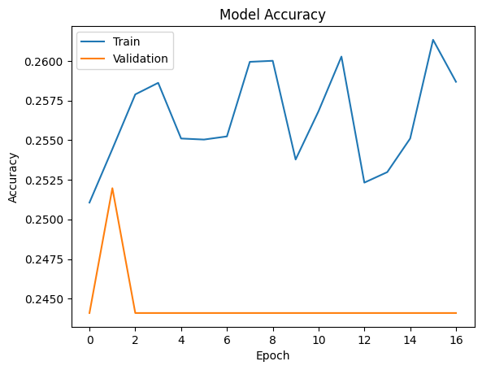

```python
model_en.evaluate(color_test_df)
# Plot
plot(history_en)
```

```python
# Clear
clear()
```

**Observations and Insights:__** We also tried a larger batch, however the transfer learning issue is still present. This has been the poorest performance, we can discard this model.

**Note: You can even go back and build your own architecture on top of the VGG16 Transfer layer and see if you can improve the performance.**

**Think About It:**

- What is your overall performance of these Transfer Learning Architectures? Can we draw a comparison of these models' performances. Are we satisfied with the accuracies that we have received? The overall performance of transfer learning has been poor. This might be because we need a better architecture, implementation, or perhaps these models are not appropriate for our needs. This can be because our images are in black and white, and the ImageNet is trained on multiple objects and all of their images are color. The accuracy of the models has been decreasing progressively.
- Do you think our issue lies with 'rgb' color_mode? Yes, as the original datasets differs from our own. Color might be a vary important factor.

Now that we have tried multiple pre-trained models, let's build a complex CNN architecture and see if we can get better performance.

## **Building a Complex Neural Network Architecture**

In this section, we will build a more complex Convolutional Neural Network Model that has close to as many parameters as we had in our Transfer Learning Models. However, we will have only 1 input channel for our input images.

## **Creating our Data Loaders**

In this section, we are creating data loaders which we will use as inputs to the more Complicated Convolutional Neural Network. We will go ahead with color_mode = 'grayscale'.

```python
# Data loaders created previously
# gray_train_df
# gray_test_df
```

### **Model Building**

- Try building a layer with 5 Convolutional Blocks and see if performance increases.

```python
# Create model function
def final_model():
  # Initialize sequential model
  model = Sequential()
  # 1st conv layer, 64 neurons, kernel size (2,2)
  model.add(Conv2D(64, (3,3), padding = 'same', input_shape = (48,48,1)))
  # 1st Norm, before activation to normalize activations
  model.add(BatchNormalization())
  # 1st Leaky Relu
  model.add(LeakyReLU(alpha=0.1))
  # 1st Pooling
  model.add(MaxPooling2D(2,2))
  model.add(Dropout(0.2))

  # 2nd Conv layer, 128 neurons
  model.add(Conv2D(128, (3,3), padding = 'same'))
  # 2nd Norm
  model.add(BatchNormalization())
  # 2nd Leaky Relu
  model.add(LeakyReLU(alpha=0.1))
  # 2nd Pooling
  model.add(MaxPooling2D(2,2))
  model.add(Dropout(0.2))

  # 3rd Conv, 256 neurons
  model.add(Conv2D(256, (3,3), padding = 'same'))
    # 3rd Norm
  model.add(BatchNormalization())
  # 3rd Leaky Relu
  model.add(LeakyReLU(alpha=0.1))
  # 3rd Pooling
  model.add(MaxPooling2D(2,2))
  model.add(Dropout(0.2))

  # 4th Conv, 512 neurons
  model.add(Conv2D(512, (3,3), padding = 'same'))
  # 4th Norm
  model.add(BatchNormalization())
  # 4th Leaky Relu
  model.add(LeakyReLU(alpha=0.1))
  # 4th Pooling
  model.add(MaxPooling2D(2,2))
  # Drop
  model.add(Dropout(0.4))

  # 5th Conv, 512 neurons
  model.add(Conv2D(512, (3,3), padding = 'same'))
  # 5th Norm
  model.add(BatchNormalization())
  # 5th Leaky Relu
  model.add(LeakyReLU(alpha=0.1))
  # 5th Pooling
  model.add(MaxPooling2D(2,2))



  # Flatten
  model.add(Flatten())
  # First dense, 512 Neurons
  model.add(Dense(512))
  # Act. Funct. Leaky Relu
  model.add(LeakyReLU(alpha=0.1))
  # Drop
  model.add(Dropout(0.4))

  # 2nd Dense
  model.add(Dense(256))
  # Act. Funct. Leaky Relu
  model.add(LeakyReLU(alpha=0.1))
  # Drop
  model.add(Dropout(0.2))

  # 3rd Dense layer, 128 neurons
  model.add(Dense(128))
  # Act. Funct. Leaky Relu
  model.add(LeakyReLU(alpha=0.1))
  # Drop
  model.add(Dropout(0.2))

  # Dense final, output, 4 categories
  model.add(Dense(4, activation = 'softmax'))
  # Optimizer
  opt = Adam(learning_rate=0.0001)
  # Compile
  model.compile(optimizer = opt, loss = 'categorical_crossentropy', metrics = ['accuracy'])
  # Return
  return model
```

### **Compiling and Training the Model**

```python
model_f = final_model()
print(model_f.summary())
```

```
Model: "sequential"
```

```
┏━━━━━━━━━━━━━━━━━━━━━━━━━━━━━━━━━┳━━━━━━━━━━━━━━━━━━━━━━━━┳━━━━━━━━━━━━━━━┓
┃ Layer (type)                    ┃ Output Shape           ┃       Param # ┃
┡━━━━━━━━━━━━━━━━━━━━━━━━━━━━━━━━━╇━━━━━━━━━━━━━━━━━━━━━━━━╇━━━━━━━━━━━━━━━┩
│ conv2d (Conv2D)                 │ (None, 48, 48, 64)     │           640 │
├─────────────────────────────────┼────────────────────────┼───────────────┤
│ batch_normalization             │ (None, 48, 48, 64)     │           256 │
│ (BatchNormalization)            │                        │               │
├─────────────────────────────────┼────────────────────────┼───────────────┤
│ leaky_re_lu (LeakyReLU)         │ (None, 48, 48, 64)     │             0 │
├─────────────────────────────────┼────────────────────────┼───────────────┤
│ max_pooling2d (MaxPooling2D)    │ (None, 24, 24, 64)     │             0 │
├─────────────────────────────────┼────────────────────────┼───────────────┤
│ dropout (Dropout)               │ (None, 24, 24, 64)     │             0 │
├─────────────────────────────────┼────────────────────────┼───────────────┤
│ conv2d_1 (Conv2D)               │ (None, 24, 24, 128)    │        73,856 │
├─────────────────────────────────┼────────────────────────┼───────────────┤
│ batch_normalization_1           │ (None, 24, 24, 128)    │           512 │
│ (BatchNormalization)            │                        │               │
├─────────────────────────────────┼────────────────────────┼───────────────┤
│ leaky_re_lu_1 (LeakyReLU)       │ (None, 24, 24, 128)    │             0 │
├─────────────────────────────────┼────────────────────────┼───────────────┤
│ max_pooling2d_1 (MaxPooling2D)  │ (None, 12, 12, 128)    │             0 │
├─────────────────────────────────┼────────────────────────┼───────────────┤
│ dropout_1 (Dropout)             │ (None, 12, 12, 128)    │             0 │
├─────────────────────────────────┼────────────────────────┼───────────────┤
│ conv2d_2 (Conv2D)               │ (None, 12, 12, 256)    │       295,168 │
├─────────────────────────────────┼────────────────────────┼───────────────┤
│ batch_normalization_2           │ (None, 12, 12, 256)    │         1,024 │
│ (BatchNormalization)            │                        │               │
├─────────────────────────────────┼────────────────────────┼───────────────┤
│ leaky_re_lu_2 (LeakyReLU)       │ (None, 12, 12, 256)    │             0 │
├─────────────────────────────────┼────────────────────────┼───────────────┤
│ max_pooling2d_2 (MaxPooling2D)  │ (None, 6, 6, 256)      │             0 │
├─────────────────────────────────┼────────────────────────┼───────────────┤
│ dropout_2 (Dropout)             │ (None, 6, 6, 256)      │             0 │
├─────────────────────────────────┼────────────────────────┼───────────────┤
│ conv2d_3 (Conv2D)               │ (None, 6, 6, 512)      │     1,180,160 │
├─────────────────────────────────┼────────────────────────┼───────────────┤
│ batch_normalization_3           │ (None, 6, 6, 512)      │         2,048 │
│ (BatchNormalization)            │                        │               │
```

[output cut: 23 more lines]

```
├─────────────────────────────────┼────────────────────────┼───────────────┤
│ dense_1 (Dense)                 │ (None, 256)            │       131,328 │
├─────────────────────────────────┼────────────────────────┼───────────────┤
│ leaky_re_lu_6 (LeakyReLU)       │ (None, 256)            │             0 │
├─────────────────────────────────┼────────────────────────┼───────────────┤
│ dropout_5 (Dropout)             │ (None, 256)            │             0 │
├─────────────────────────────────┼────────────────────────┼───────────────┤
│ dense_2 (Dense)                 │ (None, 128)            │        32,896 │
├─────────────────────────────────┼────────────────────────┼───────────────┤
│ leaky_re_lu_7 (LeakyReLU)       │ (None, 128)            │             0 │
├─────────────────────────────────┼────────────────────────┼───────────────┤
│ dropout_6 (Dropout)             │ (None, 128)            │             0 │
├─────────────────────────────────┼────────────────────────┼───────────────┤
│ dense_3 (Dense)                 │ (None, 4)              │           516 │
└─────────────────────────────────┴────────────────────────┴───────────────┘
```

```
 Total params: 4,342,916 (16.57 MB)
```

```
 Trainable params: 4,339,972 (16.56 MB)
```

```
 Non-trainable params: 2,944 (11.50 KB)
```

```
None
```

```python
# Introduce callbacks to improve training
# Save checkpoint in best values
checkpoint = ModelCheckpoint("./modelf.h5", monitor='val_acc', verbose=1, save_best_only=True, mode='max')


# Stop when the improvement is low
early_stopping = EarlyStopping(monitor = 'val_loss',
                          min_delta = 0.00001,     # Changing factors to see behaviour in model
                          patience = 10,
                          verbose = 1,
                          restore_best_weights = True
                          )
# Reduce learning rate when validation loss flattens
reduce_learningrate = ReduceLROnPlateau(monitor = 'val_loss',
                              factor = 0.3,     # Changing factors to see behaviour in model
                              patience = 4,
                              verbose = 1,
                              min_delta = 0.0001) # Changing factors to see behaviour in model

callbacks_list = [early_stopping, checkpoint, reduce_learningrate]
```

```python
# Fit
history_f = model_f.fit(gray_train_df, validation_data = gray_test_df, batch_size = 32, verbose = 1, epochs = 30, callbacks = callbacks_list)
```

```
472/472 ━━━━━━━━━━━━━━━━━━━━ 30s 36ms/step - accuracy: 0.2913 - loss: 1.4833 - val_accuracy: 0.2598 - val_loss: 1.4133 - learning_rate: 1.0000e-04
472/472 ━━━━━━━━━━━━━━━━━━━━ 8s 16ms/step - accuracy: 0.3191 - loss: 1.3584 - val_accuracy: 0.2598 - val_loss: 1.3928 - learning_rate: 1.0000e-04
472/472 ━━━━━━━━━━━━━━━━━━━━ 10s 16ms/step - accuracy: 0.3440 - loss: 1.3253 - val_accuracy: 0.2835 - val_loss: 1.3465 - learning_rate: 1.0000e-04
472/472 ━━━━━━━━━━━━━━━━━━━━ 10s 16ms/step - accuracy: 0.3825 - loss: 1.2840 - val_accuracy: 0.4094 - val_loss: 1.2297 - learning_rate: 1.0000e-04
472/472 ━━━━━━━━━━━━━━━━━━━━ 10s 16ms/step - accuracy: 0.3940 - loss: 1.2575 - val_accuracy: 0.4409 - val_loss: 1.1773 - learning_rate: 1.0000e-04
472/472 ━━━━━━━━━━━━━━━━━━━━ 8s 16ms/step - accuracy: 0.4148 - loss: 1.2200 - val_accuracy: 0.3780 - val_loss: 1.1683 - learning_rate: 1.0000e-04
472/472 ━━━━━━━━━━━━━━━━━━━━ 10s 17ms/step - accuracy: 0.4426 - loss: 1.1821 - val_accuracy: 0.5197 - val_loss: 0.9726 - learning_rate: 1.0000e-04
472/472 ━━━━━━━━━━━━━━━━━━━━ 10s 16ms/step - accuracy: 0.4914 - loss: 1.1326 - val_accuracy: 0.5748 - val_loss: 0.8711 - learning_rate: 1.0000e-04
472/472 ━━━━━━━━━━━━━━━━━━━━ 10s 16ms/step - accuracy: 0.5140 - loss: 1.0986 - val_accuracy: 0.5039 - val_loss: 0.9398 - learning_rate: 1.0000e-04
472/472 ━━━━━━━━━━━━━━━━━━━━ 10s 16ms/step - accuracy: 0.5345 - loss: 1.0554 - val_accuracy: 0.5669 - val_loss: 0.8193 - learning_rate: 1.0000e-04
472/472 ━━━━━━━━━━━━━━━━━━━━ 10s 16ms/step - accuracy: 0.5512 - loss: 1.0335 - val_accuracy: 0.5512 - val_loss: 0.9979 - learning_rate: 1.0000e-04
472/472 ━━━━━━━━━━━━━━━━━━━━ 10s 16ms/step - accuracy: 0.5657 - loss: 1.0006 - val_accuracy: 0.5906 - val_loss: 0.7720 - learning_rate: 1.0000e-04
472/472 ━━━━━━━━━━━━━━━━━━━━ 7s 16ms/step - accuracy: 0.5842 - loss: 0.9733 - val_accuracy: 0.6299 - val_loss: 0.7518 - learning_rate: 1.0000e-04
472/472 ━━━━━━━━━━━━━━━━━━━━ 11s 16ms/step - accuracy: 0.5923 - loss: 0.9518 - val_accuracy: 0.6457 - val_loss: 0.7285 - learning_rate: 1.0000e-04
472/472 ━━━━━━━━━━━━━━━━━━━━ 8s 16ms/step - accuracy: 0.6041 - loss: 0.9279 - val_accuracy: 0.6142 - val_loss: 0.7578 - learning_rate: 1.0000e-04
472/472 ━━━━━━━━━━━━━━━━━━━━ 8s 16ms/step - accuracy: 0.6120 - loss: 0.9073 - val_accuracy: 0.6457 - val_loss: 0.7040 - learning_rate: 1.0000e-04
472/472 ━━━━━━━━━━━━━━━━━━━━ 11s 17ms/step - accuracy: 0.6266 - loss: 0.9028 - val_accuracy: 0.6772 - val_loss: 0.6833 - learning_rate: 1.0000e-04
472/472 ━━━━━━━━━━━━━━━━━━━━ 10s 16ms/step - accuracy: 0.6280 - loss: 0.8870 - val_accuracy: 0.6614 - val_loss: 0.6931 - learning_rate: 1.0000e-04
472/472 ━━━━━━━━━━━━━━━━━━━━ 7s 15ms/step - accuracy: 0.6449 - loss: 0.8657 - val_accuracy: 0.7165 - val_loss: 0.6388 - learning_rate: 1.0000e-04
472/472 ━━━━━━━━━━━━━━━━━━━━ 10s 16ms/step - accuracy: 0.6509 - loss: 0.8446 - val_accuracy: 0.6929 - val_loss: 0.6288 - learning_rate: 1.0000e-04
472/472 ━━━━━━━━━━━━━━━━━━━━ 10s 16ms/step - accuracy: 0.6472 - loss: 0.8491 - val_accuracy: 0.7244 - val_loss: 0.6855 - learning_rate: 1.0000e-04
472/472 ━━━━━━━━━━━━━━━━━━━━ 7s 16ms/step - accuracy: 0.6585 - loss: 0.8302 - val_accuracy: 0.7244 - val_loss: 0.6214 - learning_rate: 1.0000e-04
472/472 ━━━━━━━━━━━━━━━━━━━━ 8s 16ms/step - accuracy: 0.6544 - loss: 0.8276 - val_accuracy: 0.7165 - val_loss: 0.6572 - learning_rate: 1.0000e-04
472/472 ━━━━━━━━━━━━━━━━━━━━ 8s 16ms/step - accuracy: 0.6644 - loss: 0.8166 - val_accuracy: 0.7087 - val_loss: 0.6410 - learning_rate: 1.0000e-04
472/472 ━━━━━━━━━━━━━━━━━━━━ 10s 15ms/step - accuracy: 0.6546 - loss: 0.8178 - val_accuracy: 0.7638 - val_loss: 0.6318 - learning_rate: 1.0000e-04
472/472 ━━━━━━━━━━━━━━━━━━━━ 0s 16ms/step - accuracy: 0.6668 - loss: 0.7988
Epoch 26: ReduceLROnPlateau reducing learning rate to 2.9999999242136255e-05.
472/472 ━━━━━━━━━━━━━━━━━━━━ 8s 16ms/step - accuracy: 0.6668 - loss: 0.7988 - val_accuracy: 0.7244 - val_loss: 0.6254 - learning_rate: 1.0000e-04
472/472 ━━━━━━━━━━━━━━━━━━━━ 8s 16ms/step - accuracy: 0.6759 - loss: 0.7789 - val_accuracy: 0.7402 - val_loss: 0.6025 - learning_rate: 3.0000e-05
472/472 ━━━━━━━━━━━━━━━━━━━━ 8s 17ms/step - accuracy: 0.6767 - loss: 0.7690 - val_accuracy: 0.7559 - val_loss: 0.5877 - learning_rate: 3.0000e-05
472/472 ━━━━━━━━━━━━━━━━━━━━ 8s 16ms/step - accuracy: 0.6819 - loss: 0.7669 - val_accuracy: 0.7480 - val_loss: 0.5947 - learning_rate: 3.0000e-05
472/472 ━━━━━━━━━━━━━━━━━━━━ 7s 15ms/step - accuracy: 0.6905 - loss: 0.7480 - val_accuracy: 0.7717 - val_loss: 0.5848 - learning_rate: 3.0000e-05
Restoring model weights from the end of the best epoch: 30.
```

### **Evaluating the Model on Test Set**

```
4/4 ━━━━━━━━━━━━━━━━━━━━ 0s 13ms/step - accuracy: 0.7461 - loss: 0.5494
```

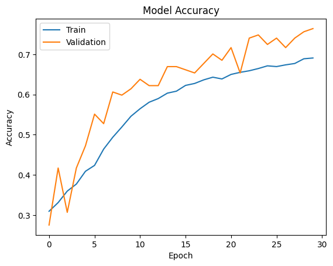

```python
model_f.evaluate(gray_test_df)
# Plot
plot(history_f)
```

**Fine Tunning on models**

After looking at this CNN, this can be too complex, let's decrease the number of neurons and use Global Average Pooling instead of flatten due to the small nature of the data set. (averages each feature map)

```python
clear()
```

```python
# Create model function
def final_model_t():
  # Initialize sequential model
  model = Sequential()
  # 1st conv layer, 64 neurons, kernel size (2,2)
  model.add(Conv2D(32, (3,3), padding = 'same', input_shape = (48,48,1)))
  # 1st Norm, before activation to normalize activations
  model.add(BatchNormalization())
  # 1st Leaky Relu
  model.add(LeakyReLU(alpha=0.1))
  # 1st Pooling
  model.add(MaxPooling2D(2,2))

  # 2nd Conv layer, 128 neurons
  model.add(Conv2D(64, (3,3), padding = 'same'))
  # 2nd Norm
  model.add(BatchNormalization())
  # 2nd Leaky Relu
  model.add(LeakyReLU(alpha=0.1))
  # 2nd Pooling
  model.add(MaxPooling2D(2,2))


  # 3rd Conv, 256 neurons
  model.add(Conv2D(128, (3,3), padding = 'same'))
    # 3rd Norm
  model.add(BatchNormalization())
  # 3rd Leaky Relu
  model.add(LeakyReLU(alpha=0.1))
  # 3rd Pooling
  model.add(MaxPooling2D(2,2))

  # 4th Conv, 512 neurons
  model.add(Conv2D(256, (3,3), padding = 'same'))
  # 4th Norm
  model.add(BatchNormalization())
  # 4th Leaky Relu
  model.add(LeakyReLU(alpha=0.1))
  # 4th Pooling
  model.add(MaxPooling2D(2,2))


  # 5th Conv, 512 neurons
  model.add(Conv2D(512, (3,3), padding = 'same'))
  # 5th Norm
  model.add(BatchNormalization())
  # 5th Leaky Relu
  model.add(LeakyReLU(alpha=0.1))
  # 5th Pooling
  model.add(MaxPooling2D(2,2))



  # Flatten
  model.add(GlobalAveragePooling2D())
  # First dense, 512 Neurons
  model.add(Dense(512))
  # Act. Funct. Leaky Relu
  model.add(LeakyReLU(alpha=0.1))
  # Drop
  model.add(Dropout(0.4))

  # 2nd Dense
  model.add(Dense(256))
  # Act. Funct. Leaky Relu
  model.add(LeakyReLU(alpha=0.1))
  # Drop
  model.add(Dropout(0.3))

  # 3rd Dense layer, 128 neurons
  model.add(Dense(128))
  # Act. Funct. Leaky Relu
  model.add(LeakyReLU(alpha=0.1))

  # Dense final, output, 4 categories
  model.add(Dense(4, activation = 'softmax'))
  # Optimizer
  opt = Adam(learning_rate=0.0005)
  # Compile
  model.compile(optimizer = opt, loss = 'categorical_crossentropy', metrics = ['accuracy'])
  # Return
  return model
```

```python
model_t = final_model_t()
print(model_t.summary())
```

```
Model: "sequential"
```

```
┏━━━━━━━━━━━━━━━━━━━━━━━━━━━━━━━━━┳━━━━━━━━━━━━━━━━━━━━━━━━┳━━━━━━━━━━━━━━━┓
┃ Layer (type)                    ┃ Output Shape           ┃       Param # ┃
┡━━━━━━━━━━━━━━━━━━━━━━━━━━━━━━━━━╇━━━━━━━━━━━━━━━━━━━━━━━━╇━━━━━━━━━━━━━━━┩
│ conv2d (Conv2D)                 │ (None, 48, 48, 32)     │           320 │
├─────────────────────────────────┼────────────────────────┼───────────────┤
│ batch_normalization             │ (None, 48, 48, 32)     │           128 │
│ (BatchNormalization)            │                        │               │
├─────────────────────────────────┼────────────────────────┼───────────────┤
│ leaky_re_lu (LeakyReLU)         │ (None, 48, 48, 32)     │             0 │
├─────────────────────────────────┼────────────────────────┼───────────────┤
│ max_pooling2d (MaxPooling2D)    │ (None, 24, 24, 32)     │             0 │
├─────────────────────────────────┼────────────────────────┼───────────────┤
│ conv2d_1 (Conv2D)               │ (None, 24, 24, 64)     │        18,496 │
├─────────────────────────────────┼────────────────────────┼───────────────┤
│ batch_normalization_1           │ (None, 24, 24, 64)     │           256 │
│ (BatchNormalization)            │                        │               │
├─────────────────────────────────┼────────────────────────┼───────────────┤
│ leaky_re_lu_1 (LeakyReLU)       │ (None, 24, 24, 64)     │             0 │
├─────────────────────────────────┼────────────────────────┼───────────────┤
│ max_pooling2d_1 (MaxPooling2D)  │ (None, 12, 12, 64)     │             0 │
├─────────────────────────────────┼────────────────────────┼───────────────┤
│ conv2d_2 (Conv2D)               │ (None, 12, 12, 128)    │        73,856 │
├─────────────────────────────────┼────────────────────────┼───────────────┤
│ batch_normalization_2           │ (None, 12, 12, 128)    │           512 │
│ (BatchNormalization)            │                        │               │
├─────────────────────────────────┼────────────────────────┼───────────────┤
│ leaky_re_lu_2 (LeakyReLU)       │ (None, 12, 12, 128)    │             0 │
├─────────────────────────────────┼────────────────────────┼───────────────┤
│ max_pooling2d_2 (MaxPooling2D)  │ (None, 6, 6, 128)      │             0 │
├─────────────────────────────────┼────────────────────────┼───────────────┤
│ conv2d_3 (Conv2D)               │ (None, 6, 6, 256)      │       295,168 │
├─────────────────────────────────┼────────────────────────┼───────────────┤
│ batch_normalization_3           │ (None, 6, 6, 256)      │         1,024 │
│ (BatchNormalization)            │                        │               │
├─────────────────────────────────┼────────────────────────┼───────────────┤
│ leaky_re_lu_3 (LeakyReLU)       │ (None, 6, 6, 256)      │             0 │
├─────────────────────────────────┼────────────────────────┼───────────────┤
│ max_pooling2d_3 (MaxPooling2D)  │ (None, 3, 3, 256)      │             0 │
├─────────────────────────────────┼────────────────────────┼───────────────┤
│ conv2d_4 (Conv2D)               │ (None, 3, 3, 512)      │     1,180,160 │
```

[output cut: 14 more lines]

```
├─────────────────────────────────┼────────────────────────┼───────────────┤
│ dropout (Dropout)               │ (None, 512)            │             0 │
├─────────────────────────────────┼────────────────────────┼───────────────┤
│ dense_1 (Dense)                 │ (None, 256)            │       131,328 │
├─────────────────────────────────┼────────────────────────┼───────────────┤
│ leaky_re_lu_6 (LeakyReLU)       │ (None, 256)            │             0 │
├─────────────────────────────────┼────────────────────────┼───────────────┤
│ dropout_1 (Dropout)             │ (None, 256)            │             0 │
├─────────────────────────────────┼────────────────────────┼───────────────┤
│ dense_2 (Dense)                 │ (None, 128)            │        32,896 │
├─────────────────────────────────┼────────────────────────┼───────────────┤
│ leaky_re_lu_7 (LeakyReLU)       │ (None, 128)            │             0 │
├─────────────────────────────────┼────────────────────────┼───────────────┤
│ dense_3 (Dense)                 │ (None, 4)              │           516 │
└─────────────────────────────────┴────────────────────────┴───────────────┘
```

```
 Total params: 1,999,364 (7.63 MB)
```

```
 Trainable params: 1,997,380 (7.62 MB)
```

```
 Non-trainable params: 1,984 (7.75 KB)
```

```
None
```

```python
# Introduce callbacks to improve training
# Save checkpoint in best values
checkpoint = ModelCheckpoint("./modelf.h5", monitor='val_acc', verbose=1, save_best_only=True, mode='max')


# Stop when the improvement is low
early_stopping = EarlyStopping(monitor = 'val_loss',
                          min_delta = 0.0001,     # Changing factors to see behaviour in model
                          patience = 10,
                          verbose = 1,
                          restore_best_weights = True
                          )
# Reduce learning rate when validation loss flattens
reduce_learningrate = ReduceLROnPlateau(monitor = 'val_loss',
                              factor = 0.4,     # Changing factors to see behaviour in model
                              patience = 4,
                              verbose = 1,
                              min_delta = 0.0001) # Changing factors to see behaviour in model

callbacks_list = [early_stopping, checkpoint, reduce_learningrate]
```

```python
# Fit
history_t = model_t.fit(gray_train_df, validation_data = gray_test_df, batch_size = 32, verbose = 1, epochs = 30, callbacks = callbacks_list)
```

```
472/472 ━━━━━━━━━━━━━━━━━━━━ 18s 20ms/step - accuracy: 0.3146 - loss: 1.4234 - val_accuracy: 0.3543 - val_loss: 1.4900 - learning_rate: 5.0000e-04
472/472 ━━━━━━━━━━━━━━━━━━━━ 16s 19ms/step - accuracy: 0.4563 - loss: 1.1668 - val_accuracy: 0.5118 - val_loss: 1.1115 - learning_rate: 5.0000e-04
472/472 ━━━━━━━━━━━━━━━━━━━━ 7s 11ms/step - accuracy: 0.5665 - loss: 0.9948 - val_accuracy: 0.6693 - val_loss: 0.7823 - learning_rate: 5.0000e-04
472/472 ━━━━━━━━━━━━━━━━━━━━ 9s 9ms/step - accuracy: 0.6201 - loss: 0.9115 - val_accuracy: 0.6535 - val_loss: 0.7744 - learning_rate: 5.0000e-04
472/472 ━━━━━━━━━━━━━━━━━━━━ 4s 8ms/step - accuracy: 0.6486 - loss: 0.8552 - val_accuracy: 0.6063 - val_loss: 0.9864 - learning_rate: 5.0000e-04
472/472 ━━━━━━━━━━━━━━━━━━━━ 6s 12ms/step - accuracy: 0.6606 - loss: 0.8150 - val_accuracy: 0.7087 - val_loss: 0.6746 - learning_rate: 5.0000e-04
472/472 ━━━━━━━━━━━━━━━━━━━━ 9s 9ms/step - accuracy: 0.6741 - loss: 0.7878 - val_accuracy: 0.7087 - val_loss: 0.6359 - learning_rate: 5.0000e-04
472/472 ━━━━━━━━━━━━━━━━━━━━ 6s 12ms/step - accuracy: 0.6825 - loss: 0.7690 - val_accuracy: 0.8031 - val_loss: 0.6213 - learning_rate: 5.0000e-04
472/472 ━━━━━━━━━━━━━━━━━━━━ 9s 9ms/step - accuracy: 0.6961 - loss: 0.7460 - val_accuracy: 0.6850 - val_loss: 0.7591 - learning_rate: 5.0000e-04
472/472 ━━━━━━━━━━━━━━━━━━━━ 5s 11ms/step - accuracy: 0.7013 - loss: 0.7335 - val_accuracy: 0.6693 - val_loss: 0.7168 - learning_rate: 5.0000e-04
472/472 ━━━━━━━━━━━━━━━━━━━━ 10s 11ms/step - accuracy: 0.7060 - loss: 0.7181 - val_accuracy: 0.6772 - val_loss: 0.6638 - learning_rate: 5.0000e-04
467/472 ━━━━━━━━━━━━━━━━━━━━ 0s 8ms/step - accuracy: 0.7146 - loss: 0.7012
Epoch 12: ReduceLROnPlateau reducing learning rate to 0.00020000000949949026.
472/472 ━━━━━━━━━━━━━━━━━━━━ 4s 9ms/step - accuracy: 0.7146 - loss: 0.7012 - val_accuracy: 0.7559 - val_loss: 0.6311 - learning_rate: 5.0000e-04
472/472 ━━━━━━━━━━━━━━━━━━━━ 5s 8ms/step - accuracy: 0.7344 - loss: 0.6617 - val_accuracy: 0.7795 - val_loss: 0.6040 - learning_rate: 2.0000e-04
472/472 ━━━━━━━━━━━━━━━━━━━━ 7s 12ms/step - accuracy: 0.7420 - loss: 0.6381 - val_accuracy: 0.7323 - val_loss: 0.6533 - learning_rate: 2.0000e-04
472/472 ━━━━━━━━━━━━━━━━━━━━ 9s 10ms/step - accuracy: 0.7532 - loss: 0.6155 - val_accuracy: 0.7953 - val_loss: 0.5420 - learning_rate: 2.0000e-04
472/472 ━━━━━━━━━━━━━━━━━━━━ 5s 10ms/step - accuracy: 0.7507 - loss: 0.6146 - val_accuracy: 0.7795 - val_loss: 0.5731 - learning_rate: 2.0000e-04
472/472 ━━━━━━━━━━━━━━━━━━━━ 4s 8ms/step - accuracy: 0.7610 - loss: 0.5944 - val_accuracy: 0.7795 - val_loss: 0.5950 - learning_rate: 2.0000e-04
472/472 ━━━━━━━━━━━━━━━━━━━━ 5s 10ms/step - accuracy: 0.7544 - loss: 0.5953 - val_accuracy: 0.7638 - val_loss: 0.5858 - learning_rate: 2.0000e-04
472/472 ━━━━━━━━━━━━━━━━━━━━ 0s 11ms/step - accuracy: 0.7616 - loss: 0.5833
Epoch 19: ReduceLROnPlateau reducing learning rate to 8.000000379979611e-05.
472/472 ━━━━━━━━━━━━━━━━━━━━ 5s 11ms/step - accuracy: 0.7616 - loss: 0.5832 - val_accuracy: 0.7559 - val_loss: 0.5653 - learning_rate: 2.0000e-04
472/472 ━━━━━━━━━━━━━━━━━━━━ 4s 8ms/step - accuracy: 0.7731 - loss: 0.5589 - val_accuracy: 0.7874 - val_loss: 0.5492 - learning_rate: 8.0000e-05
472/472 ━━━━━━━━━━━━━━━━━━━━ 5s 11ms/step - accuracy: 0.7818 - loss: 0.5458 - val_accuracy: 0.7953 - val_loss: 0.5420 - learning_rate: 8.0000e-05
472/472 ━━━━━━━━━━━━━━━━━━━━ 9s 8ms/step - accuracy: 0.7865 - loss: 0.5348 - val_accuracy: 0.7559 - val_loss: 0.5800 - learning_rate: 8.0000e-05
466/472 ━━━━━━━━━━━━━━━━━━━━ 0s 12ms/step - accuracy: 0.7872 - loss: 0.5326
Epoch 23: ReduceLROnPlateau reducing learning rate to 3.200000210199505e-05.
472/472 ━━━━━━━━━━━━━━━━━━━━ 6s 12ms/step - accuracy: 0.7872 - loss: 0.5324 - val_accuracy: 0.7795 - val_loss: 0.5549 - learning_rate: 8.0000e-05
472/472 ━━━━━━━━━━━━━━━━━━━━ 4s 8ms/step - accuracy: 0.7959 - loss: 0.5195 - val_accuracy: 0.7795 - val_loss: 0.5404 - learning_rate: 3.2000e-05
472/472 ━━━━━━━━━━━━━━━━━━━━ 7s 11ms/step - accuracy: 0.7967 - loss: 0.5133 - val_accuracy: 0.7717 - val_loss: 0.5589 - learning_rate: 3.2000e-05
472/472 ━━━━━━━━━━━━━━━━━━━━ 9s 9ms/step - accuracy: 0.7981 - loss: 0.5143 - val_accuracy: 0.7795 - val_loss: 0.5503 - learning_rate: 3.2000e-05
472/472 ━━━━━━━━━━━━━━━━━━━━ 6s 12ms/step - accuracy: 0.7957 - loss: 0.5070 - val_accuracy: 0.7717 - val_loss: 0.5381 - learning_rate: 3.2000e-05
472/472 ━━━━━━━━━━━━━━━━━━━━ 9s 9ms/step - accuracy: 0.8017 - loss: 0.5002 - val_accuracy: 0.7717 - val_loss: 0.5474 - learning_rate: 3.2000e-05
472/472 ━━━━━━━━━━━━━━━━━━━━ 6s 12ms/step - accuracy: 0.8024 - loss: 0.4995 - val_accuracy: 0.7717 - val_loss: 0.5516 - learning_rate: 3.2000e-05
472/472 ━━━━━━━━━━━━━━━━━━━━ 9s 9ms/step - accuracy: 0.8013 - loss: 0.5007 - val_accuracy: 0.7717 - val_loss: 0.5583 - learning_rate: 3.2000e-05
Restoring model weights from the end of the best epoch: 27.
```

```
4/4 ━━━━━━━━━━━━━━━━━━━━ 0s 9ms/step - accuracy: 0.7878 - loss: 0.5302
```

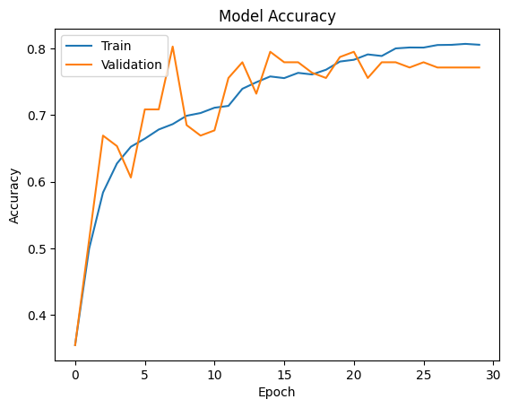

```python
model_t.evaluate(gray_test_df)
# Plot
plot(history_t)
```

We can see how the predictions improved greatly, however, we can notice how the model is overfitting. Let's drop more neurons to adjust the accuracy of the validation set.

```python
clear()
```

```python
# Create model function
def final_model2():
  # Initialize sequential model
  model = Sequential()
  # 1st conv layer, 64 neurons, kernel size (2,2)
  model.add(Conv2D(32, (3,3), padding = 'same', input_shape = (48,48,1)))
  # 1st Norm, before activation to normalize activations
  model.add(BatchNormalization())
  # 1st Leaky Relu
  model.add(LeakyReLU(alpha=0.1))
  # 1st Pooling
  model.add(MaxPooling2D(2,2))

  # 2nd Conv layer, 128 neurons
  model.add(Conv2D(64, (3,3), padding = 'same'))
  # 2nd Norm
  model.add(BatchNormalization())
  # 2nd Leaky Relu
  model.add(LeakyReLU(alpha=0.1))
  # 2nd Pooling
  model.add(MaxPooling2D(2,2))


  # 3rd Conv, 256 neurons
  model.add(Conv2D(128, (3,3), padding = 'same'))
    # 3rd Norm
  model.add(BatchNormalization())
  # 3rd Leaky Relu
  model.add(LeakyReLU(alpha=0.1))
  # 3rd Pooling
  model.add(MaxPooling2D(2,2))

  # 4th Conv, 512 neurons
  model.add(Conv2D(256, (3,3), padding = 'same'))
  # 4th Norm
  model.add(BatchNormalization())
  # 4th Leaky Relu
  model.add(LeakyReLU(alpha=0.1))
  # 4th Pooling
  model.add(MaxPooling2D(2,2))
  # Drop
  model.add(Dropout(0.2))

  # 5th Conv, 512 neurons
  model.add(Conv2D(512, (3,3), padding = 'same'))
  # 5th Norm
  model.add(BatchNormalization())
  # 5th Leaky Relu
  model.add(LeakyReLU(alpha=0.1))
  # 5th Pooling
  model.add(MaxPooling2D(2,2))
  # Drop
  model.add(Dropout(0.2))



  # Flatten
  model.add(GlobalAveragePooling2D())
  # First dense, 512 Neurons
  model.add(Dense(512))
  # Act. Funct. Leaky Relu
  model.add(LeakyReLU(alpha=0.1))
  # Drop
  model.add(Dropout(0.4))

  # 2nd Dense
  model.add(Dense(256))
  # Act. Funct. Leaky Relu
  model.add(LeakyReLU(alpha=0.1))
  # Drop
  model.add(Dropout(0.3))

  # 3rd Dense layer, 128 neurons
  model.add(Dense(128))
  # Act. Funct. Leaky Relu
  model.add(LeakyReLU(alpha=0.1))
  # Drop
  model.add(Dropout(0.2))

  # Dense final, output, 4 categories
  model.add(Dense(4, activation = 'softmax'))
  # Optimizer
  opt = Adam(learning_rate=0.0005)
  # Compile
  model.compile(optimizer = opt, loss = 'categorical_crossentropy', metrics = ['accuracy'])
  # Return
  return model
```

```python
model_f2 = final_model2()
print(model_f2.summary())
```

```
Model: "sequential"
```

```
┏━━━━━━━━━━━━━━━━━━━━━━━━━━━━━━━━━┳━━━━━━━━━━━━━━━━━━━━━━━━┳━━━━━━━━━━━━━━━┓
┃ Layer (type)                    ┃ Output Shape           ┃       Param # ┃
┡━━━━━━━━━━━━━━━━━━━━━━━━━━━━━━━━━╇━━━━━━━━━━━━━━━━━━━━━━━━╇━━━━━━━━━━━━━━━┩
│ conv2d (Conv2D)                 │ (None, 48, 48, 32)     │           320 │
├─────────────────────────────────┼────────────────────────┼───────────────┤
│ batch_normalization             │ (None, 48, 48, 32)     │           128 │
│ (BatchNormalization)            │                        │               │
├─────────────────────────────────┼────────────────────────┼───────────────┤
│ leaky_re_lu (LeakyReLU)         │ (None, 48, 48, 32)     │             0 │
├─────────────────────────────────┼────────────────────────┼───────────────┤
│ max_pooling2d (MaxPooling2D)    │ (None, 24, 24, 32)     │             0 │
├─────────────────────────────────┼────────────────────────┼───────────────┤
│ conv2d_1 (Conv2D)               │ (None, 24, 24, 64)     │        18,496 │
├─────────────────────────────────┼────────────────────────┼───────────────┤
│ batch_normalization_1           │ (None, 24, 24, 64)     │           256 │
│ (BatchNormalization)            │                        │               │
├─────────────────────────────────┼────────────────────────┼───────────────┤
│ leaky_re_lu_1 (LeakyReLU)       │ (None, 24, 24, 64)     │             0 │
├─────────────────────────────────┼────────────────────────┼───────────────┤
│ max_pooling2d_1 (MaxPooling2D)  │ (None, 12, 12, 64)     │             0 │
├─────────────────────────────────┼────────────────────────┼───────────────┤
│ conv2d_2 (Conv2D)               │ (None, 12, 12, 128)    │        73,856 │
├─────────────────────────────────┼────────────────────────┼───────────────┤
│ batch_normalization_2           │ (None, 12, 12, 128)    │           512 │
│ (BatchNormalization)            │                        │               │
├─────────────────────────────────┼────────────────────────┼───────────────┤
│ leaky_re_lu_2 (LeakyReLU)       │ (None, 12, 12, 128)    │             0 │
├─────────────────────────────────┼────────────────────────┼───────────────┤
│ max_pooling2d_2 (MaxPooling2D)  │ (None, 6, 6, 128)      │             0 │
├─────────────────────────────────┼────────────────────────┼───────────────┤
│ conv2d_3 (Conv2D)               │ (None, 6, 6, 256)      │       295,168 │
├─────────────────────────────────┼────────────────────────┼───────────────┤
│ batch_normalization_3           │ (None, 6, 6, 256)      │         1,024 │
│ (BatchNormalization)            │                        │               │
├─────────────────────────────────┼────────────────────────┼───────────────┤
│ leaky_re_lu_3 (LeakyReLU)       │ (None, 6, 6, 256)      │             0 │
├─────────────────────────────────┼────────────────────────┼───────────────┤
│ max_pooling2d_3 (MaxPooling2D)  │ (None, 3, 3, 256)      │             0 │
├─────────────────────────────────┼────────────────────────┼───────────────┤
│ dropout (Dropout)               │ (None, 3, 3, 256)      │             0 │
```

[output cut: 20 more lines]

```
├─────────────────────────────────┼────────────────────────┼───────────────┤
│ dense_1 (Dense)                 │ (None, 256)            │       131,328 │
├─────────────────────────────────┼────────────────────────┼───────────────┤
│ leaky_re_lu_6 (LeakyReLU)       │ (None, 256)            │             0 │
├─────────────────────────────────┼────────────────────────┼───────────────┤
│ dropout_3 (Dropout)             │ (None, 256)            │             0 │
├─────────────────────────────────┼────────────────────────┼───────────────┤
│ dense_2 (Dense)                 │ (None, 128)            │        32,896 │
├─────────────────────────────────┼────────────────────────┼───────────────┤
│ leaky_re_lu_7 (LeakyReLU)       │ (None, 128)            │             0 │
├─────────────────────────────────┼────────────────────────┼───────────────┤
│ dropout_4 (Dropout)             │ (None, 128)            │             0 │
├─────────────────────────────────┼────────────────────────┼───────────────┤
│ dense_3 (Dense)                 │ (None, 4)              │           516 │
└─────────────────────────────────┴────────────────────────┴───────────────┘
```

```
 Total params: 1,999,364 (7.63 MB)
```

```
 Trainable params: 1,997,380 (7.62 MB)
```

```
 Non-trainable params: 1,984 (7.75 KB)
```

```
None
```

```python
# Introduce callbacks to improve training
# Save checkpoint in best values
checkpoint = ModelCheckpoint("./modelf.h5", monitor='val_acc', verbose=1, save_best_only=True, mode='max')


# Stop when the improvement is low
early_stopping = EarlyStopping(monitor = 'val_loss',
                          min_delta = 0.0001,     # Changing factors to see behaviour in model
                          patience = 10,
                          verbose = 1,
                          restore_best_weights = True
                          )
# Reduce learning rate when validation loss flattens
reduce_learningrate = ReduceLROnPlateau(monitor = 'val_loss',
                              factor = 0.4,     # Changing factors to see behaviour in model
                              patience = 4,
                              verbose = 1,
                              min_delta = 0.0001) # Changing factors to see behaviour in model

callbacks_list = [early_stopping, checkpoint, reduce_learningrate]
```

```python
# Fit
history_f2 = model_f2.fit(gray_train_df, validation_data = gray_test_df, batch_size = 32, verbose = 1, epochs = 30, callbacks = callbacks_list)
```

```
472/472 ━━━━━━━━━━━━━━━━━━━━ 21s 24ms/step - accuracy: 0.2991 - loss: 1.4748 - val_accuracy: 0.2520 - val_loss: 1.4783 - learning_rate: 5.0000e-04
472/472 ━━━━━━━━━━━━━━━━━━━━ 4s 9ms/step - accuracy: 0.3937 - loss: 1.2495 - val_accuracy: 0.4724 - val_loss: 1.0701 - learning_rate: 5.0000e-04
472/472 ━━━━━━━━━━━━━━━━━━━━ 5s 10ms/step - accuracy: 0.4853 - loss: 1.1204 - val_accuracy: 0.6063 - val_loss: 0.8942 - learning_rate: 5.0000e-04
472/472 ━━━━━━━━━━━━━━━━━━━━ 4s 9ms/step - accuracy: 0.5709 - loss: 0.9926 - val_accuracy: 0.6142 - val_loss: 0.8338 - learning_rate: 5.0000e-04
472/472 ━━━━━━━━━━━━━━━━━━━━ 7s 12ms/step - accuracy: 0.6064 - loss: 0.9367 - val_accuracy: 0.5827 - val_loss: 0.9640 - learning_rate: 5.0000e-04
472/472 ━━━━━━━━━━━━━━━━━━━━ 4s 8ms/step - accuracy: 0.6336 - loss: 0.8755 - val_accuracy: 0.6693 - val_loss: 0.7892 - learning_rate: 5.0000e-04
472/472 ━━━━━━━━━━━━━━━━━━━━ 4s 8ms/step - accuracy: 0.6467 - loss: 0.8557 - val_accuracy: 0.7402 - val_loss: 0.6690 - learning_rate: 5.0000e-04
472/472 ━━━━━━━━━━━━━━━━━━━━ 6s 12ms/step - accuracy: 0.6622 - loss: 0.8315 - val_accuracy: 0.6929 - val_loss: 0.7281 - learning_rate: 5.0000e-04
472/472 ━━━━━━━━━━━━━━━━━━━━ 4s 8ms/step - accuracy: 0.6684 - loss: 0.8070 - val_accuracy: 0.7165 - val_loss: 0.6850 - learning_rate: 5.0000e-04
472/472 ━━━━━━━━━━━━━━━━━━━━ 5s 9ms/step - accuracy: 0.6835 - loss: 0.7799 - val_accuracy: 0.7165 - val_loss: 0.6952 - learning_rate: 5.0000e-04
465/472 ━━━━━━━━━━━━━━━━━━━━ 0s 10ms/step - accuracy: 0.6889 - loss: 0.7670
Epoch 11: ReduceLROnPlateau reducing learning rate to 0.00020000000949949026.
472/472 ━━━━━━━━━━━━━━━━━━━━ 6s 10ms/step - accuracy: 0.6889 - loss: 0.7669 - val_accuracy: 0.7795 - val_loss: 0.6709 - learning_rate: 5.0000e-04
472/472 ━━━━━━━━━━━━━━━━━━━━ 4s 8ms/step - accuracy: 0.7083 - loss: 0.7262 - val_accuracy: 0.7717 - val_loss: 0.6333 - learning_rate: 2.0000e-04
472/472 ━━━━━━━━━━━━━━━━━━━━ 7s 12ms/step - accuracy: 0.7123 - loss: 0.7061 - val_accuracy: 0.7638 - val_loss: 0.5782 - learning_rate: 2.0000e-04
472/472 ━━━━━━━━━━━━━━━━━━━━ 8s 9ms/step - accuracy: 0.7158 - loss: 0.6941 - val_accuracy: 0.7480 - val_loss: 0.5718 - learning_rate: 2.0000e-04
472/472 ━━━━━━━━━━━━━━━━━━━━ 5s 10ms/step - accuracy: 0.7242 - loss: 0.6798 - val_accuracy: 0.7795 - val_loss: 0.6018 - learning_rate: 2.0000e-04
472/472 ━━━━━━━━━━━━━━━━━━━━ 5s 9ms/step - accuracy: 0.7298 - loss: 0.6750 - val_accuracy: 0.7795 - val_loss: 0.6021 - learning_rate: 2.0000e-04
472/472 ━━━━━━━━━━━━━━━━━━━━ 5s 8ms/step - accuracy: 0.7279 - loss: 0.6681 - val_accuracy: 0.7874 - val_loss: 0.6077 - learning_rate: 2.0000e-04
472/472 ━━━━━━━━━━━━━━━━━━━━ 7s 12ms/step - accuracy: 0.7304 - loss: 0.6614 - val_accuracy: 0.7559 - val_loss: 0.5511 - learning_rate: 2.0000e-04
472/472 ━━━━━━━━━━━━━━━━━━━━ 9s 9ms/step - accuracy: 0.7371 - loss: 0.6518 - val_accuracy: 0.7638 - val_loss: 0.5854 - learning_rate: 2.0000e-04
472/472 ━━━━━━━━━━━━━━━━━━━━ 6s 12ms/step - accuracy: 0.7413 - loss: 0.6421 - val_accuracy: 0.7638 - val_loss: 0.5959 - learning_rate: 2.0000e-04
472/472 ━━━━━━━━━━━━━━━━━━━━ 9s 9ms/step - accuracy: 0.7421 - loss: 0.6382 - val_accuracy: 0.8110 - val_loss: 0.6188 - learning_rate: 2.0000e-04
472/472 ━━━━━━━━━━━━━━━━━━━━ 5s 10ms/step - accuracy: 0.7415 - loss: 0.6393 - val_accuracy: 0.8346 - val_loss: 0.5227 - learning_rate: 2.0000e-04
472/472 ━━━━━━━━━━━━━━━━━━━━ 5s 9ms/step - accuracy: 0.7472 - loss: 0.6258 - val_accuracy: 0.7953 - val_loss: 0.5843 - learning_rate: 2.0000e-04
472/472 ━━━━━━━━━━━━━━━━━━━━ 6s 12ms/step - accuracy: 0.7410 - loss: 0.6319 - val_accuracy: 0.8110 - val_loss: 0.5438 - learning_rate: 2.0000e-04
472/472 ━━━━━━━━━━━━━━━━━━━━ 4s 9ms/step - accuracy: 0.7472 - loss: 0.6194 - val_accuracy: 0.7874 - val_loss: 0.6393 - learning_rate: 2.0000e-04
469/472 ━━━━━━━━━━━━━━━━━━━━ 0s 8ms/step - accuracy: 0.7474 - loss: 0.6116
Epoch 26: ReduceLROnPlateau reducing learning rate to 8.000000379979611e-05.
472/472 ━━━━━━━━━━━━━━━━━━━━ 5s 8ms/step - accuracy: 0.7474 - loss: 0.6116 - val_accuracy: 0.7559 - val_loss: 0.6383 - learning_rate: 2.0000e-04
472/472 ━━━━━━━━━━━━━━━━━━━━ 6s 12ms/step - accuracy: 0.7609 - loss: 0.5987 - val_accuracy: 0.8268 - val_loss: 0.5170 - learning_rate: 8.0000e-05
472/472 ━━━━━━━━━━━━━━━━━━━━ 9s 9ms/step - accuracy: 0.7636 - loss: 0.5857 - val_accuracy: 0.8346 - val_loss: 0.4871 - learning_rate: 8.0000e-05
472/472 ━━━━━━━━━━━━━━━━━━━━ 6s 12ms/step - accuracy: 0.7657 - loss: 0.5905 - val_accuracy: 0.8425 - val_loss: 0.4982 - learning_rate: 8.0000e-05
472/472 ━━━━━━━━━━━━━━━━━━━━ 10s 10ms/step - accuracy: 0.7654 - loss: 0.5828 - val_accuracy: 0.8504 - val_loss: 0.5180 - learning_rate: 8.0000e-05
Restoring model weights from the end of the best epoch: 28.
```

```
4/4 ━━━━━━━━━━━━━━━━━━━━ 0s 12ms/step - accuracy: 0.8672 - loss: 0.4545
```

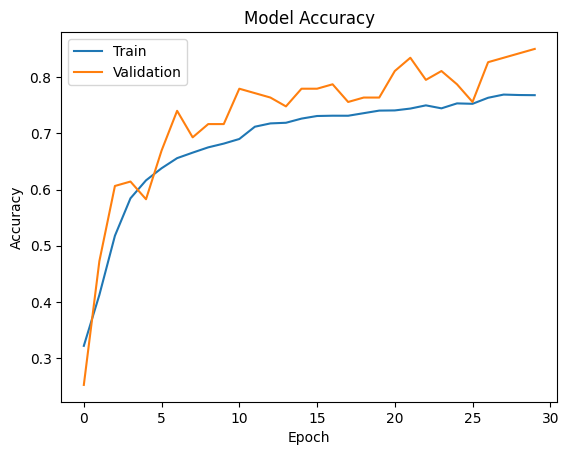

```python
model_f2.evaluate(gray_test_df)
# Plot
plot(history_f2)
```

**Observations and Insights:** The model behaved correctly, achieving our best accuracy score , and we reduced the overfitting. We can choose this as our final model — the layers were progressive, which gave us our best results. This will be our final chosen model.

### **Plotting the Confusion Matrix for the chosen final model**

```
4/4 ━━━━━━━━━━━━━━━━━━━━ 1s 186ms/step
              precision    recall  f1-score   support

           0       0.90      0.87      0.89        31
           1       0.76      0.78      0.77        32
           2       0.71      0.78      0.75        32
           3       1.00      0.91      0.95        32

    accuracy                           0.83       127
   macro avg       0.84      0.83      0.84       127
weighted avg       0.84      0.83      0.84       127
```

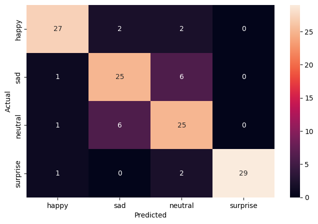

```python
# Plot the confusion matrix and generate a classification report for the model

# Set arrays
test_images = []
test_labels = []

# Append them
for batch in gray_test_df:
    batch_images, batch_labels = batch
    test_images.append(batch_images.numpy())
    test_labels.append(batch_labels.numpy())

# Combine all image batches into one array
test_images = np.concatenate(test_images, axis=0)
test_labels = np.concatenate(test_labels, axis=0)

# Predict
pred = model_f2.predict(test_images)
pred = np.argmax(pred, axis = 1)
y_true = np.argmax(test_labels, axis = 1)

# Printing the classification report
print(classification_report(y_true, pred))

# Plotting the heatmap using confusion matrix
cm = confusion_matrix(y_true, pred)
plt.figure(figsize = (8, 5))
sns.heatmap(cm, annot = True,  fmt = '.0f', xticklabels = ['happy', 'sad', 'neutral', 'surprise'], yticklabels = ['happy', 'sad', 'neutral', 'surprise'])
plt.ylabel('Actual')
plt.xlabel('Predicted')
plt.show()
```

```python
# Speed
import time

total_time = 0
total_images = 0

for batch_images, t in gray_test_df:
    batch_size = batch_images.shape[0]

    start_time = time.time()
    t = model_f2.predict(batch_images, verbose=0)
    end_time = time.time()

    total_time += (end_time - start_time)
    total_images += batch_size

avg_time_per_image = (total_time / total_images) * 1000  # in milliseconds

print(f"Avg time per image: {avg_time_per_image:.2f} ms")
```

```
Avg time per image: 2.35 ms
```

```python
model_f2.save('model_f2.keras')
model_f2.save('/content/Model/model_f2.keras', save_format='tf')
```

**Observations and Insights:** We achieved an optimal model at the end, with the help of fine tunning we built a custom CNN that met the requirements for our very specific dataset. We obtained an accuracy of 0.83 and an F1-score of 0.75 on the lowest class. We can notice that "Surprise" is the most recognizable feature, along with "Happy." "Neutral" and "Sad" got mixed up, as their features are similar.

## **Conclusion:**

The size of the test data worked against us, as it was too small, making validation difficult. We tried different approaches to mitigate this situation: data augmentation and transfer learning. However, due to the nature of our dataset, the transfer learning was not successful as those structures and weights were trained on different data, making it difficult to train our model; it was counterproductive.

The original channel of the dataset was a focal point; the best approach was to build our own CNN and tailor it to the task, which we successfully achieved. However, with a larger dataset, we can hope to achieve better results

### **Refined insights**:

- What are the most meaningful insights from the data relevant to the problem? The size and quality of the data are vital. Two of our biggest challenges were the size of the dataset for validation and the grayscale images, which made transfer learning difficult.

### **Comparison of various techniques and their relative performance**:

- How do different techniques perform? Which one is performing relatively better? Is there scope to improve the performance further?

Simple CNNs were a good start—low accuracy but really fast. Slightly more complex CNNs gave better results. When we tried transfer learning, the contrasting nature of our dataset and the data on which the models were trained gave awful results, with less than 0.5 accuracy in some cases. A more complex, tuned, and custom CNN gave better results. It would be very difficult to improve performance without improving our original dataset.

### **Proposal for the final solution design**:

- What model do you propose to be adopted? Why is this the best solution to adopt? I propose the final custom tuned model, known in this notebook as model_f2. This is the best solution for this problem. It has the best accuracy of all of our models, and it has been tuned even more this task.

# Executive Summary:

**What are the most important ﬁndings from the analysis done in Milestone?**

During the Milestone analysis, many obstacles were found. One of the key findings concerned the properties of the original dataset: it was small, and the test dataset was even smaller, containing some corrupted images or non-face images that made training difficult. We therefore removed them. Another key finding related to the color scheme; grayscale requires unique treatment and training approaches, which made transfer learning unviable.

Given the small dataset size, very complex neural networks (like the one created near the end) and those with multiple layers in transfer learning failed to detect our patterns effectively. There were significant fluctuations during validation. we could see this as "jumps" in the history plot.

The final finding involved how can results vary during fine-tuning. Certain functions and layers improved the model (like Global Average Pooling), while others negatively impacted performance (such as adding too many neurons at the beginning), making it slow. Monitoring training was also challenging, as insufficient patience could trigger early stopping.

In conclusion, achieving optimal results requires careful balance between dataset characteristics and network complexity/features, along with meticulous tuning.

**Describe the ﬁnal proposed model speciﬁcations**

The chosen model is model_f2, it is a refined version of our final model.

- **General Description:**

It consists of 5 blocks, where the neurons increase progressively. After that, the data is compacted with the averages of each category, which continues to be classified in 3 more layers where neurons decrease. Finally, we have the layer in which the data is classified into 4 categories, the learning rate is set, and the model starts to train.

- **Tecnhical description and specifications:**

We start the model and select the first convolutional block, increasing the kernel size to 3×3 and selecting grayscale input.

We have 5 convolutional blocks where the neurons increase progressively: 32, 64, 128, 256, 512. Each block normalizes the batch before applying the activation function, for which we selected LeakyReLU.

After that, we include pooling layers and, toward the end, implement dropout to avoid overfitting. Following this, we use Global Average Pooling, which flattens the image while preserving the most important features.

We then reduce the neuron count to detect general features again, maintaining dropout layers. Finally, we set the classification layer with the softmax function to match the expected classes and set the learning rate to 0.0005, which showed better and faster results than 0.0001.

# Problem and solution summary

**Provide the summary of the problem**

Communication has been the root of progress since ancient times. As we evolved, much of our communication has been non-verbal: 55% nonverbal, 38% vocal, and only 7% words*. Our ability to communicate with computers also needs to evolve, and with the help of data science, we can enable more complete virtual communication.

Facial emotion detection has many applications worldwide, including in healthcare, human-computer interaction, marketing, and security.

We need to develop a data driven solution, a model capable of detecting human emotions. For simplicity, we will start with just four categories: "Sad," "Happy," "Neutral," and "Surprised." We have access to a pre-classified grayscale dataset of human emotions. We will use it to train our model and later test its performance.

*Mehrabian, A. (1981). Silent messages: Implicit communication of emotions and attitudes (2nd ed.). Wadsworth Pub. Co.

**State the reasons for the proposed solution design**

For the solution, I have developed a custom CNN model that correctly predicts our emotions with a simple architecture.

It has been chosen because it consistently provides accurate results across all targets, with an accuracy of 0.83. It has been modified and tuned to the task to provide the best results on the given data, giving a speed of 2.3 miliseconds.

**How it would affect the problem/business?**

It would solve our current problem using a simple first-solution approach. In a customer-business-based application, emotion detection could be used to adapt the solution or interaction in a more user-friendly way, improving customer experience. This could also help in marketing, on how a focus group reacts to certain products or advertisements. This solution accurately detects four basic emotions, allowing the user experience or marketing strategy to adjust depending on whether the customer is happy or sad.

If we aimed to use this in the medical field, further development would be necessary to capture a wider spectrum of emotions and microexpressions, enabling the detection of conditions such as depression or other diverse diagnoses.

# Recommendations for implementation

**What are some key recommendations to implement the solution?**

A key solution would be to use a black-and-white camera, as color can confuse the model. We also need additional software that loads, utilizes the model and applies it in real time, Open CV can really help us. Additionally, we need to ensure the camera is focused on the face to guarantee the model works correctly.

**What are the key actionables for stakeholders?**

For the stakeholders that want to improve their customer experience or excel in their marketing:

- Develop software that uses our model in real time.
- Use a grayscale camera setup to reduce input noise and improve model accuracy, as color was shown to degrade performance.
- Ensure the area is well-lit and the face is centered in the camera.
- Deploy the real-time solution.
- Collect and measure data on customers and their reactions to your products or services.
- Check for improvements in your services or products, and how customers react.
- Expand the dataset with more emotions and images.
- Plan for future development of a more complete model.

**What is the expected beneﬁt and/or costs (List the beneﬁts of the solution. State some rational assumptions to put forward some numbers on costs/beneﬁts for stakeholders)?**

For marketing solutions, we can benefit from emotional live feedback on products. This can be used to improve and refine advertising. Naturally, this will increase sales and reduce the marketing budget, as only targeted and emotion-responsive ads will be published, resulting in more conversions.

As for the solution costs, we would only need a grayscale camera, software integration (development between 1 and 2 weeks), and cloud/storage services.

We can expect the following benefits: increased sales, personalized ads, real-time feedback, and reduced marketing costs.

Let’s assume a scenario:

- Your company runs digital ads with a monthly marketing budget of $10,000.
- Average conversion rate without emotion detection: 2%.
- Emotion-responsive targeting increases conversion by just 1% (to 3%).
- Product profit per conversion: $50.
- Emotion detection system implementation cost: $300/month (cloud + maintenance).

In a 10,000 budget scenario, if our ads trigger an emotional response and conversions increase by just 1%, revenue could increase by 5,000.

**What are the potential risks or challenges of the proposed solution design?**

The main challenge would be that emotions that are outside of our categories will not be classified or they will be classified incorrectly into our current options. Along with this design, the model can have issues with color images. Increasing the dataset would be the best option for a better model in the future.

**What further analysis needs to be done or what other associated problems need to be solved?**

We need to address the main issue: increasing the dataset size. This will significantly improve prediction quality and accuracy. However, adopting a color-based approach could be even more beneficial, as it would allow us to utilize transfer learning and leverage existing face datasets. This could yield better results with less training time and data.

Additionally, for future development and improvement, we should expand the dataset to include more emotions. The spectrum of human emotions and microexpressions is vast, and our model should detect many of them.